# Beta to Release Matching: Modeling

Mariana de Oliveira Santos Silva

Last Updated: janeiro 17, 2020

# Introduction

The goal of this project is to utilize statistical matching methods to search for a subset of Beta clients that are representative of Release. The specific use-case of this proof-of-concept is utilizing performance, configuration, and environment covariates of the clients for matching. Validation of the matching is performed on a hold-out set of Firefox **user engagement** covariates.

# Loading the data

```r
## Loading the training dataset

load("~/GitHub/ff-beta-release-matching/poc/EDA/data_milestone2_df_train_validate_20191025.RData")
```

| rows | columns | discrete_columns | continuous_columns | all_missing_columns | total_missing_values | complete_rows | total_observations | memory_usage |
| --- | --- | --- | --- | --- | --- | --- | --- | --- |
| 302819 | 58 | 20 | 38 | 0 | 0 | 302819 | 17563502 | 135686992 |

```r
f <- freq(df_train_f$label)
```

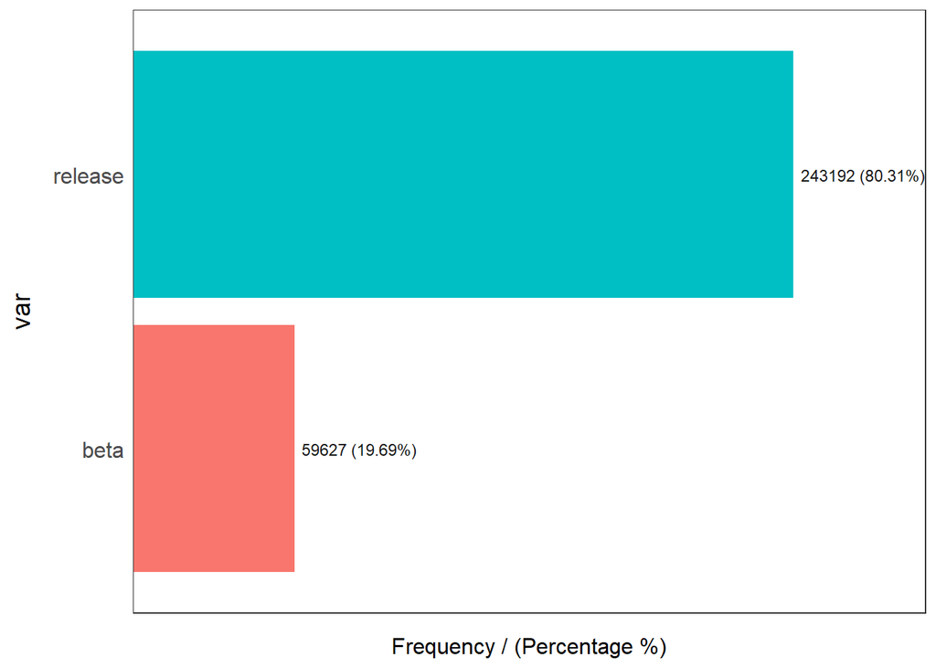

```r
levels(df_train_f$label) <- c(FALSE,TRUE)
df_train_f$label <- as.logical(df_train_f$label)
```

## Observations

- 302,819 observations: 59,627 beta (“treated”) and 243,192 release (“control”)
- Covariants:
- Environment
  - cpu_cores
  - cpu_cores_cat
  - cpu_speed_mhz
  - cpu_speed_cat
  - cpu_vendor
  - cpu_l2_cache_kb
  - cpu_l2_cache_kb_cat
  - memory_mb
  - memory_cat
  - os_version
  - is_wow64
  - distro_id_norm
  - install_year
- Geo
  - country
  - timezone_offset
  - timezone_cat
  - locale
- Settings
  - num_bookmarks
  - num_addons
  - sync_configured
  - fxa_configured
  - is_default_browser
  - default_search_engine
- Page Load
  - FX_PAGE_LOAD_MS_2_PARENT
  - TIME_TO_DOM_COMPLETE_MS
  - TIME_TO_DOM_CONTENT_LOADED_END_MS
  - TIME_TO_LOAD_EVENT_END_MS
  - TIME_TO_DOM_INTERACTIVE_MS
  - TIME_TO_NON_BLANK_PAINT_MS
- Startup
  - startup_ms
  - startup_ms_max
- Stability
  - content_crashes
- Browser engagement
  - active_hours
  - active_hours_max
  - uri_count
  - uri_count_max
  - search_count
  - search_count_max
  - num_pages
  - num_pages_max
  - daily_max_tabs
  - daily_max_tabs_max
  - daily_unique_domains
  - daily_unique_domains_max
  - daily_tabs_opened
  - daily_tabs_opened_max
- Frequency of Browser Usage
  - num_active_days
  - daily_num_sessions_started
  - daily_num_sessions_started_max
  - session_length
  - session_length_max
  - profile_age
  - profile_age_cat

```r
df_release <- df_train_f %>% filter(label == TRUE)
df_beta <- df_train_f %>% filter(label == FALSE)
```

```r
# sampling for beta overrepresentation
n_beta <- nrow(df_beta)
build_df <- function(multiple){
  df <- df_release %>%
    sample_n(size = round(n_beta / multiple)) %>%
    rbind(df_beta)
}

df_1x <- build_df(1)
df_2x <- build_df(2)
df_4x <- build_df(4)
```

```r
# downsampling
df_1x_sm <- df_1x %>% sample_n(size = 70000)
df_2x_sm <- df_2x %>% sample_n(size = 70000)
df_4x_sm <- df_4x %>% sample_n(size = 70000)
```

```r
f <- freq(as.factor(df_1x_sm$label)) # ~ 50% - 50%
```

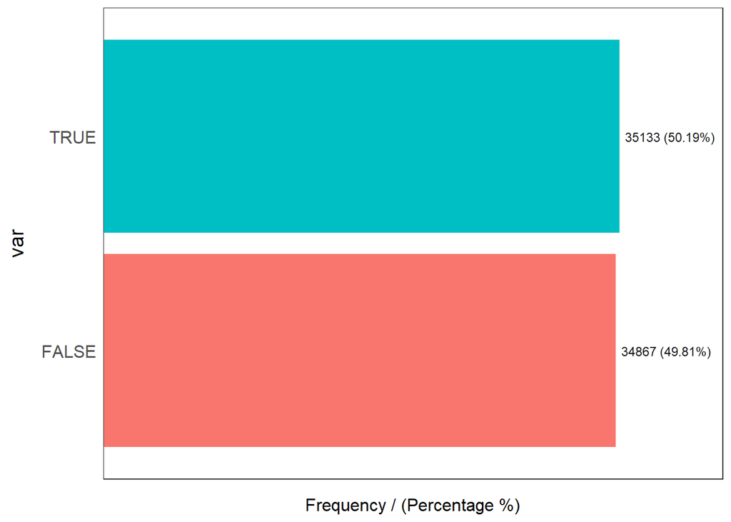

```r
f <- freq(as.factor(df_2x_sm$label)) # ~ 70% - 30%
```

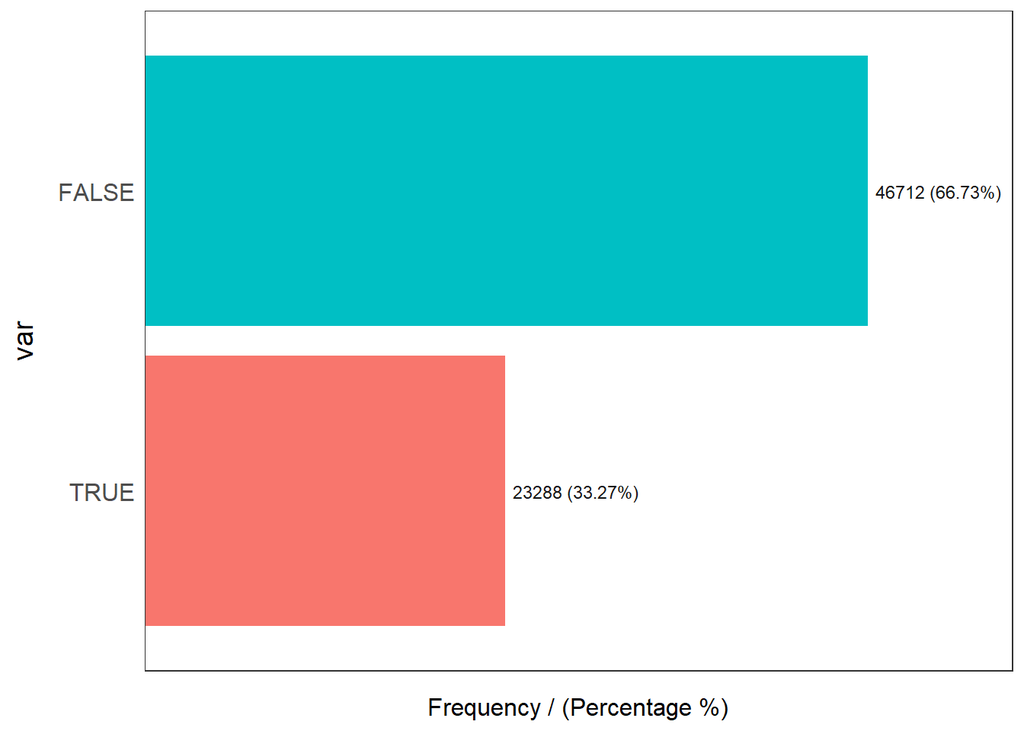

```r
f <- freq(as.factor(df_4x_sm$label)) # ~ 80% - 20%
```

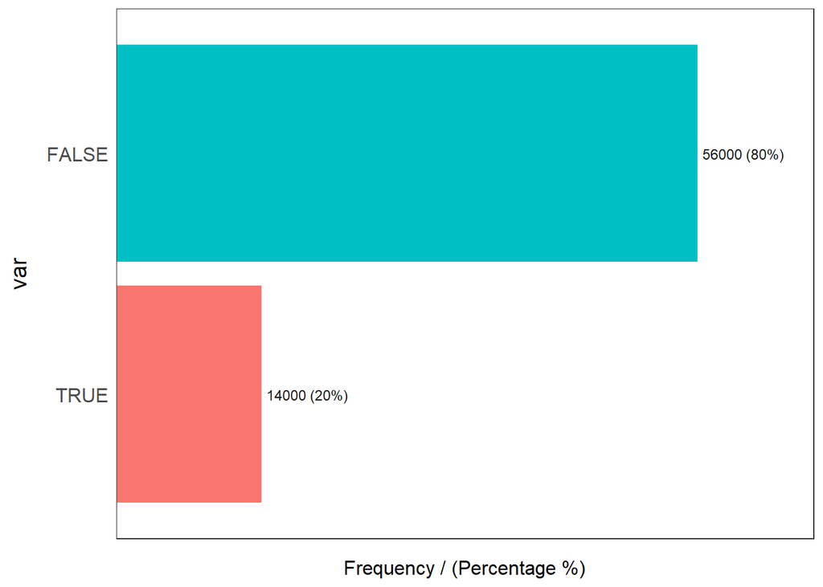

# Covariates

```r
engagement <- c('active_hours','active_hours_max','uri_count','uri_count_max','search_count','search_count_max','num_pages','num_pages_max','daily_max_tabs','daily_max_tabs_max','daily_unique_domains','daily_unique_domains_max','daily_tabs_opened','daily_tabs_opened_max')

usage <- c('num_active_days','daily_num_sessions_started','daily_num_sessions_started_max','session_length','session_length_max','profile_age')

environment <- c('cpu_cores','cpu_speed_mhz','cpu_l2_cache_kb','memory_mb','timezone_offset','num_bookmarks','num_addons')

page_load <- c('FX_PAGE_LOAD_MS_2_PARENT','TIME_TO_DOM_COMPLETE_MS','TIME_TO_DOM_CONTENT_LOADED_END_MS','TIME_TO_LOAD_EVENT_END_MS','TIME_TO_DOM_INTERACTIVE_MS','TIME_TO_NON_BLANK_PAINT_MS')

startup <- c('startup_ms','startup_ms_max')

stability <- c('content_crashes')
```

# Modeling

Before propensity scores are calculated, it is a good practice to determine if the two groups are balanced.

## 1. Standardized difference

The standardized difference can be used to compare the mean of continuous and binary variables between treatment groups. The standardized difference compares the difference in means in units of the pooled standard deviation and allows for the comparison of the relative balance of variables measured in different units. Although there is no universally agreed-upon criterion as to what threshold of the standardized difference can be used to indicate an important imbalance, a standard difference that is less than $0.1$ has been taken to indicate a negligible difference in the mean or prevalence of a covariate between treatment groups.

### 1x Oversampling

```r
cov <- df_1x_sm %>% select(c(engagement, usage, environment, page_load, startup, stability))
treated <- (df_1x_sm$label==FALSE)
std.diff <- apply(cov,2,function(x) 100*(mean(x[treated])- mean(x[!treated]))/(sqrt(0.5*(var(x[treated]) + var(x[!treated])))))
sort(abs(std.diff))
```

```
##                     num_pages_max                         num_pages
##                         0.5222103                         0.5440212
##                       profile_age                      search_count
##                         1.1644683                         1.2977630
##                         uri_count                  search_count_max
##                         1.6451696                         1.8481645
##                     uri_count_max                      active_hours
##                         2.6808663                         2.7366301
##          daily_unique_domains_max              daily_unique_domains
##                         2.8399691                         3.0851960
##                  active_hours_max                    startup_ms_max
##                         3.2590135                         4.9589314
##                     cpu_speed_mhz                         memory_mb
##                         5.1140137                         5.6210842
##                   cpu_l2_cache_kb                        startup_ms
##                         6.1680820                         6.4700662
##                     num_bookmarks             daily_tabs_opened_max
##                         8.2744087                         9.7327840
##                         cpu_cores                   num_active_days
##                        10.4678024                        10.9675752
##                 daily_tabs_opened                daily_max_tabs_max
##                        11.2769421                        13.7746803
##                    daily_max_tabs                session_length_max
##                        13.8709613                        17.1412753
## TIME_TO_DOM_CONTENT_LOADED_END_MS        daily_num_sessions_started
##                        18.2226888                        18.8608990
##    daily_num_sessions_started_max        TIME_TO_NON_BLANK_PAINT_MS
##                        19.7767550                        21.9777468
##                    session_length          FX_PAGE_LOAD_MS_2_PARENT
##                        23.9583340                        24.8049465
##        TIME_TO_DOM_INTERACTIVE_MS           TIME_TO_DOM_COMPLETE_MS
##                        30.7365040                        30.9363482
##         TIME_TO_LOAD_EVENT_END_MS                   timezone_offset
##                        33.5922917                        47.2691530
##                        num_addons
##                        78.4427946
```

### 2x Oversampling

```r
cov <- df_2x_sm %>% select(c(engagement, usage, environment, page_load, startup, stability))
treated <- (df_2x_sm$label==FALSE)
std.diff <- apply(cov,2,function(x) 100*(mean(x[treated])- mean(x[!treated]))/(sqrt(0.5*(var(x[treated]) + var(x[!treated])))))
sort(abs(std.diff))
```

```
##                         num_pages                     num_pages_max
##                         0.4939860                         0.5536752
##                      search_count                       profile_age
##                         1.2604321                         1.3462180
##              daily_unique_domains          daily_unique_domains_max
##                         1.3512748                         1.3678861
##                  search_count_max                         uri_count
##                         1.5168967                         1.6668739
##                     uri_count_max                      active_hours
##                         2.2983751                         3.0857414
##                  active_hours_max                    startup_ms_max
##                         3.4474424                         5.3219376
##                     cpu_speed_mhz                   cpu_l2_cache_kb
##                         6.2560392                         6.2976653
##                        startup_ms                         memory_mb
##                         6.6460142                         6.9422136
##                     num_bookmarks             daily_tabs_opened_max
##                         7.4400427                         8.5567631
##                   num_active_days                 daily_tabs_opened
##                        10.0224930                        10.1879396
##                         cpu_cores                daily_max_tabs_max
##                        12.0896069                        12.8578804
##                    daily_max_tabs                session_length_max
##                        12.9017407                        17.4464870
##        daily_num_sessions_started TIME_TO_DOM_CONTENT_LOADED_END_MS
##                        17.7436660                        18.3576122
##    daily_num_sessions_started_max        TIME_TO_NON_BLANK_PAINT_MS
##                        18.4910199                        22.6193469
##                    session_length          FX_PAGE_LOAD_MS_2_PARENT
##                        24.3702342                        25.0298616
##        TIME_TO_DOM_INTERACTIVE_MS           TIME_TO_DOM_COMPLETE_MS
##                        30.9205613                        31.2038227
##         TIME_TO_LOAD_EVENT_END_MS                   timezone_offset
##                        33.7408143                        46.8904856
##                        num_addons
##                        75.3642839
```

### 4x Oversampling

```r
cov <- df_4x_sm %>% select(c(engagement, usage, environment, page_load, startup, stability))
treated <- (df_4x_sm$label==FALSE)
std.diff <- apply(cov,2,function(x) 100*(mean(x[treated])- mean(x[!treated]))/(sqrt(0.5*(var(x[treated]) + var(x[!treated])))))
sort(abs(std.diff))
```

```
##                       profile_age                  search_count_max
##                         0.1196784                         0.5883659
##                      search_count          daily_unique_domains_max
##                         0.7507612                         1.4015082
##              daily_unique_domains                         num_pages
##                         1.4838864                         2.0115979
##                     num_pages_max                         uri_count
##                         2.0355311                         2.6756797
##                      active_hours                  active_hours_max
##                         3.0272092                         3.3208097
##                     uri_count_max                     cpu_speed_mhz
##                         3.3273588                         5.1733654
##                    startup_ms_max                         memory_mb
##                         5.3758378                         5.5256621
##                   cpu_l2_cache_kb                        startup_ms
##                         5.9547441                         6.8064507
##                     num_bookmarks             daily_tabs_opened_max
##                         7.5342840                         8.6133679
##                 daily_tabs_opened                   num_active_days
##                        10.0321953                        10.2997073
##                daily_max_tabs_max                    daily_max_tabs
##                        12.1151515                        12.4048952
##                         cpu_cores                session_length_max
##                        12.4458938                        17.0492439
##        daily_num_sessions_started TIME_TO_DOM_CONTENT_LOADED_END_MS
##                        18.7203871                        18.7373631
##    daily_num_sessions_started_max        TIME_TO_NON_BLANK_PAINT_MS
##                        19.8879362                        23.3141323
##                    session_length          FX_PAGE_LOAD_MS_2_PARENT
##                        23.8231309                        26.2261369
##        TIME_TO_DOM_INTERACTIVE_MS           TIME_TO_DOM_COMPLETE_MS
##                        31.5630583                        32.0065551
##         TIME_TO_LOAD_EVENT_END_MS                   timezone_offset
##                        34.7915436                        46.7463833
##                        num_addons
##                        78.2631029
```

## 2. Check initial balance

The package [RItools](https://cran.r-project.org/web/packages/RItools/index.html) includes the routine `XBalance` that estimates a chi-square test to which checks if there is at least one variable in the selection model for which the two groups are different.

- *How similar are treatment/control groups on X?*

### 1x Oversampling

```r
xBalance(label ~ (active_hours + active_hours_max + uri_count + uri_count_max + search_count + search_count_max + num_pages + num_pages_max + daily_max_tabs + daily_max_tabs_max + daily_unique_domains + daily_unique_domains_max + daily_tabs_opened + daily_tabs_opened_max + num_active_days + daily_num_sessions_started + daily_num_sessions_started_max + session_length + session_length_max + profile_age + cpu_cores + cpu_speed_mhz + cpu_l2_cache_kb + memory_mb + num_bookmarks + FX_PAGE_LOAD_MS_2_PARENT + TIME_TO_DOM_CONTENT_LOADED_END_MS + TIME_TO_NON_BLANK_PAINT_MS + startup_ms + startup_ms_max + content_crashes), data=df_1x_sm, report=c("chisquare.test"))
```

```
## ---Overall Test---
##         chisquare df p.value
## unstrat      3458 30       0
## ---
## Signif. codes:  0 '***' 0.001 '** ' 0.01 '*  ' 0.05 '.  ' 0.1 '   ' 1
```

### 2x Oversampling

```r
xBalance(label ~ (active_hours + active_hours_max + uri_count + uri_count_max + search_count + search_count_max + num_pages + num_pages_max + daily_max_tabs + daily_max_tabs_max + daily_unique_domains + daily_unique_domains_max + daily_tabs_opened + daily_tabs_opened_max + num_active_days + daily_num_sessions_started + daily_num_sessions_started_max + session_length_max + profile_age + cpu_cores + cpu_speed_mhz + cpu_l2_cache_kb + memory_mb + num_bookmarks + FX_PAGE_LOAD_MS_2_PARENT + TIME_TO_DOM_CONTENT_LOADED_END_MS + TIME_TO_NON_BLANK_PAINT_MS + startup_ms + startup_ms_max + content_crashes), data=df_2x_sm, report=c("chisquare.test"))
```

```
## ---Overall Test---
##         chisquare df p.value
## unstrat      2483 29       0
## ---
## Signif. codes:  0 '***' 0.001 '** ' 0.01 '*  ' 0.05 '.  ' 0.1 '   ' 1
```

### 4x Oversampling

```r
xBalance(label ~ (active_hours + active_hours_max + uri_count + uri_count_max + search_count + search_count_max + num_pages + num_pages_max + daily_max_tabs + daily_max_tabs_max + daily_unique_domains + daily_unique_domains_max + daily_tabs_opened + daily_tabs_opened_max + num_active_days + daily_num_sessions_started + daily_num_sessions_started_max + session_length + session_length_max + profile_age + cpu_cores + cpu_speed_mhz + cpu_l2_cache_kb + memory_mb + num_bookmarks + FX_PAGE_LOAD_MS_2_PARENT + TIME_TO_DOM_CONTENT_LOADED_END_MS + TIME_TO_NON_BLANK_PAINT_MS + startup_ms + startup_ms_max + content_crashes), data=df_4x_sm, report=c("chisquare.test"))
```

```
## ---Overall Test---
##         chisquare df p.value
## unstrat      1983 30       0
## ---
## Signif. codes:  0 '***' 0.001 '** ' 0.01 '*  ' 0.05 '.  ' 0.1 '   ' 1
```

### Observations

- A statistically significant chi-square will indicate that at least one of the variables included in the model is creating an imbalance between the two groups. Variables that create imbalance should be included in the selection model.

## 3. Propensity Score Estimation

Packages such as MatchIt estimates propensity scores using logistic regression as the default option. However, when estimating propensity scores using the default option, the fit of the model cannot be assessed. Therefore, it is recommended that a logistic regression is run to determine the model fit.

### Calculates the propensity score

#### 1x Oversampling

```r
ps <- glm(label ~ active_hours + active_hours_max + uri_count + uri_count_max + search_count + search_count_max + num_pages + num_pages_max + daily_max_tabs + daily_max_tabs_max + daily_unique_domains + daily_unique_domains_max + daily_tabs_opened + daily_tabs_opened_max + num_active_days + daily_num_sessions_started + daily_num_sessions_started_max + session_length + session_length_max + profile_age + cpu_cores + cpu_speed_mhz + cpu_l2_cache_kb + memory_mb + num_bookmarks + FX_PAGE_LOAD_MS_2_PARENT + TIME_TO_DOM_CONTENT_LOADED_END_MS + TIME_TO_NON_BLANK_PAINT_MS + startup_ms + startup_ms_max + content_crashes, data=df_1x_sm, family=binomial())
summary(ps)
```

```
##
## Call:
## glm(formula = label ~ active_hours + active_hours_max + uri_count +
##     uri_count_max + search_count + search_count_max + num_pages +
##     num_pages_max + daily_max_tabs + daily_max_tabs_max + daily_unique_domains +
##     daily_unique_domains_max + daily_tabs_opened + daily_tabs_opened_max +
##     num_active_days + daily_num_sessions_started + daily_num_sessions_started_max +
##     session_length + session_length_max + profile_age + cpu_cores +
##     cpu_speed_mhz + cpu_l2_cache_kb + memory_mb + num_bookmarks +
##     FX_PAGE_LOAD_MS_2_PARENT + TIME_TO_DOM_CONTENT_LOADED_END_MS +
##     TIME_TO_NON_BLANK_PAINT_MS + startup_ms + startup_ms_max +
##     content_crashes, family = binomial(), data = df_1x_sm)
##
## Deviance Residuals:
##     Min       1Q   Median       3Q      Max
## -2.4572  -1.1666   0.7543   1.1075   3.3359
##
## Coefficients: (1 not defined because of singularities)
##                                     Estimate Std. Error z value Pr(>|z|)
## (Intercept)                        5.506e-01  5.389e-02  10.217  < 2e-16
## active_hours                       1.083e-01  2.976e-02   3.639 0.000274
## active_hours_max                   8.295e-03  1.525e-02   0.544 0.586568
## uri_count                         -1.345e-04  1.100e-04  -1.222 0.221684
## uri_count_max                      5.182e-05  3.886e-05   1.334 0.182363
## search_count                       1.927e-02  5.583e-03   3.451 0.000558
## search_count_max                  -1.522e-02  2.620e-03  -5.810 6.25e-09
## num_pages                          7.237e-06  7.468e-06   0.969 0.332496
## num_pages_max                     -6.548e-06  7.461e-06  -0.878 0.380140
## daily_max_tabs                    -3.673e-03  1.451e-03  -2.531 0.011358
## daily_max_tabs_max                -2.162e-03  1.117e-03  -1.935 0.052944
## daily_unique_domains               2.615e-02  5.152e-03   5.076 3.85e-07
## daily_unique_domains_max          -5.871e-03  2.480e-03  -2.368 0.017893
## daily_tabs_opened                 -6.940e-03  8.827e-04  -7.862 3.78e-15
## daily_tabs_opened_max              8.741e-04  4.231e-04   2.066 0.038850
## num_active_days                    3.669e-02  4.442e-03   8.260  < 2e-16
## daily_num_sessions_started         1.134e-02  8.011e-03   1.416 0.156891
## daily_num_sessions_started_max     1.602e-02  4.475e-03   3.579 0.000344
## session_length                    -3.347e-02  1.681e-03 -19.910  < 2e-16
## session_length_max                 7.684e-03  7.645e-04  10.051  < 2e-16
## profile_age                        6.493e-06  1.091e-05   0.595 0.551858
```

[output cut: 39 more lines]

```
## TIME_TO_DOM_CONTENT_LOADED_END_MS
## TIME_TO_NON_BLANK_PAINT_MS        ***
## startup_ms                        ***
## startup_ms_max                    ***
## content_crashes
## ---
## Signif. codes:  0 '***' 0.001 '**' 0.01 '*' 0.05 '.' 0.1 ' ' 1
##
## (Dispersion parameter for binomial family taken to be 1)
##
##     Null deviance: 97040  on 69999  degrees of freedom
## Residual deviance: 93184  on 69969  degrees of freedom
## AIC: 93246
##
## Number of Fisher Scoring iterations: 6
```

Statistically significant estimates are identified by low (i.e., $< 0.05$) p-values. There are no clear suggestions as to whether to include in the final model all the variables (even non-significant). Some authors suggest that the final model should include not only statistically significant variables, but also variables known to be associated with selection.

Once the propensity scores have been calculated, a graphical approach can be used to assess the distributional similarity between score distributions. This graphical approach uses back to back histograms such as those created through the package Hmisc. Back to back histograms cannot be used with Mahalanobis distance, because it is a multidimensional technique.

- Attach the predicted propensity score to the datafile

```r
df_1x_sm$psvalue <- predict(ps, type="response")
```

## Back to back histogram

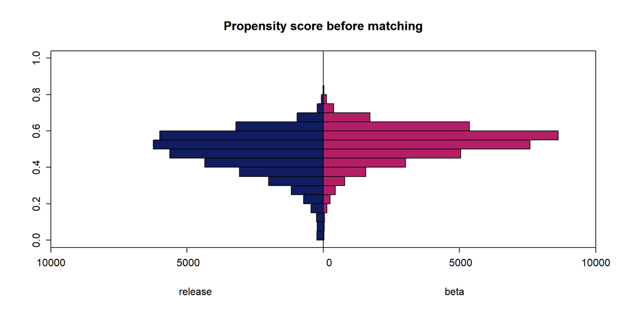

```r
out <- histbackback(split(df_1x_sm$psvalue, df_1x_sm$label), main="Propensity score before matching", xlab=c("release", "beta"))
#! just adding color
barplot(-out$left, col="#111d5e" , horiz=TRUE, space=0, add=TRUE, axes=FALSE)
barplot(out$right, col="#b21f66", horiz=TRUE, space=0, add=TRUE, axes=FALSE)
```

#### 2x Oversampling

```r
ps <- glm(label ~ active_hours + active_hours_max + uri_count + uri_count_max + search_count + search_count_max + num_pages + num_pages_max + daily_max_tabs + daily_max_tabs_max + daily_unique_domains + daily_unique_domains_max + daily_tabs_opened + daily_tabs_opened_max + num_active_days + daily_num_sessions_started + daily_num_sessions_started_max + session_length_max + profile_age + cpu_cores + cpu_speed_mhz + cpu_l2_cache_kb + memory_mb + num_bookmarks + FX_PAGE_LOAD_MS_2_PARENT + TIME_TO_DOM_CONTENT_LOADED_END_MS + TIME_TO_NON_BLANK_PAINT_MS + startup_ms + startup_ms_max + content_crashes, data=df_2x_sm, family=binomial())
summary(ps)
```

```
##
## Call:
## glm(formula = label ~ active_hours + active_hours_max + uri_count +
##     uri_count_max + search_count + search_count_max + num_pages +
##     num_pages_max + daily_max_tabs + daily_max_tabs_max + daily_unique_domains +
##     daily_unique_domains_max + daily_tabs_opened + daily_tabs_opened_max +
##     num_active_days + daily_num_sessions_started + daily_num_sessions_started_max +
##     session_length_max + profile_age + cpu_cores + cpu_speed_mhz +
##     cpu_l2_cache_kb + memory_mb + num_bookmarks + FX_PAGE_LOAD_MS_2_PARENT +
##     TIME_TO_DOM_CONTENT_LOADED_END_MS + TIME_TO_NON_BLANK_PAINT_MS +
##     startup_ms + startup_ms_max + content_crashes, family = binomial(),
##     data = df_2x_sm)
##
## Deviance Residuals:
##     Min       1Q   Median       3Q      Max
## -1.7741  -0.9381  -0.7827   1.3361   4.4261
##
## Coefficients: (1 not defined because of singularities)
##                                     Estimate Std. Error z value Pr(>|z|)
## (Intercept)                       -2.229e-01  5.634e-02  -3.957 7.60e-05
## active_hours                       6.602e-02  3.069e-02   2.152 0.031432
## active_hours_max                   2.270e-02  1.574e-02   1.442 0.149380
## uri_count                         -1.609e-04  1.165e-04  -1.381 0.167265
## uri_count_max                      3.592e-05  4.101e-05   0.876 0.381065
## search_count                       8.980e-03  5.918e-03   1.518 0.129128
## search_count_max                  -1.110e-02  2.774e-03  -4.002 6.28e-05
## num_pages                          2.213e-05  9.916e-06   2.231 0.025652
## num_pages_max                     -2.187e-05  9.910e-06  -2.207 0.027346
## daily_max_tabs                    -1.704e-03  1.809e-03  -0.942 0.346124
## daily_max_tabs_max                -4.807e-03  1.420e-03  -3.385 0.000712
## daily_unique_domains               2.756e-02  5.406e-03   5.099 3.42e-07
## daily_unique_domains_max          -5.452e-03  2.605e-03  -2.093 0.036363
## daily_tabs_opened                 -7.996e-03  9.394e-04  -8.512  < 2e-16
## daily_tabs_opened_max              1.607e-03  4.372e-04   3.677 0.000236
## num_active_days                    3.016e-02  4.636e-03   6.504 7.80e-11
## daily_num_sessions_started         1.869e-02  8.135e-03   2.297 0.021611
## daily_num_sessions_started_max     1.592e-02  4.517e-03   3.525 0.000424
## session_length_max                -6.840e-03  4.169e-04 -16.407  < 2e-16
## profile_age                       -2.109e-05  1.155e-05  -1.826 0.067792
## cpu_cores                          4.503e-02  6.504e-03   6.924 4.40e-12
```

[output cut: 37 more lines]

```
## TIME_TO_DOM_CONTENT_LOADED_END_MS
## TIME_TO_NON_BLANK_PAINT_MS        ***
## startup_ms                        ***
## startup_ms_max                    ***
## content_crashes
## ---
## Signif. codes:  0 '***' 0.001 '**' 0.01 '*' 0.05 '.' 0.1 ' ' 1
##
## (Dispersion parameter for binomial family taken to be 1)
##
##     Null deviance: 89049  on 69999  degrees of freedom
## Residual deviance: 86166  on 69970  degrees of freedom
## AIC: 86226
##
## Number of Fisher Scoring iterations: 7
```

- Attach the predicted propensity score to the datafile

```r
df_2x_sm$psvalue <- predict(ps, type="response")
```

## Back to back histogram

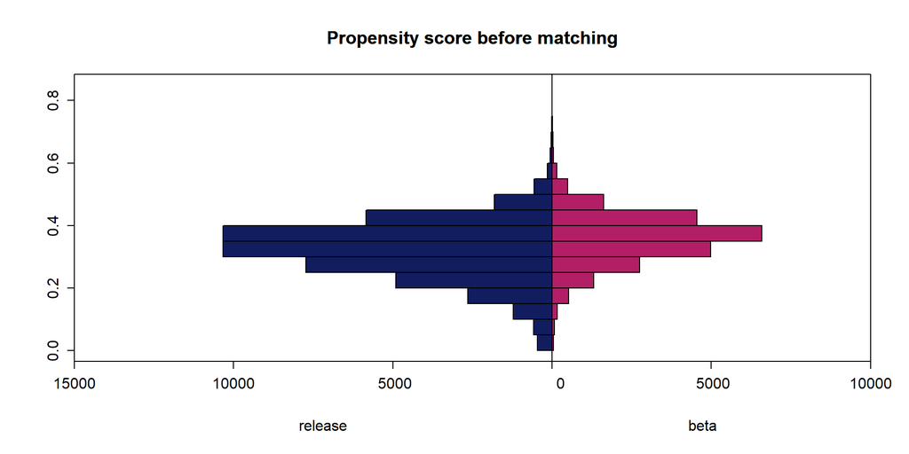

```r
out <- histbackback(split(df_2x_sm$psvalue, df_2x_sm$label), main="Propensity score before matching", xlab=c("release", "beta"))
#! just adding color
barplot(-out$left, col="#111d5e" , horiz=TRUE, space=0, add=TRUE, axes=FALSE)
barplot(out$right, col="#b21f66", horiz=TRUE, space=0, add=TRUE, axes=FALSE)
```

#### 4x Oversampling

```r
ps <- glm(label ~ active_hours + active_hours_max + uri_count + uri_count_max + search_count + search_count_max + num_pages + num_pages_max + daily_max_tabs + daily_max_tabs_max + daily_unique_domains + daily_unique_domains_max + daily_tabs_opened + daily_tabs_opened_max + num_active_days + daily_num_sessions_started + daily_num_sessions_started_max + session_length_max + profile_age + cpu_cores + cpu_speed_mhz + cpu_l2_cache_kb + memory_mb + num_bookmarks + FX_PAGE_LOAD_MS_2_PARENT + TIME_TO_DOM_CONTENT_LOADED_END_MS + TIME_TO_NON_BLANK_PAINT_MS + startup_ms + startup_ms_max + content_crashes, data=df_4x_sm, family=binomial())
summary(ps)
```

```
##
## Call:
## glm(formula = label ~ active_hours + active_hours_max + uri_count +
##     uri_count_max + search_count + search_count_max + num_pages +
##     num_pages_max + daily_max_tabs + daily_max_tabs_max + daily_unique_domains +
##     daily_unique_domains_max + daily_tabs_opened + daily_tabs_opened_max +
##     num_active_days + daily_num_sessions_started + daily_num_sessions_started_max +
##     session_length_max + profile_age + cpu_cores + cpu_speed_mhz +
##     cpu_l2_cache_kb + memory_mb + num_bookmarks + FX_PAGE_LOAD_MS_2_PARENT +
##     TIME_TO_DOM_CONTENT_LOADED_END_MS + TIME_TO_NON_BLANK_PAINT_MS +
##     startup_ms + startup_ms_max + content_crashes, family = binomial(),
##     data = df_4x_sm)
##
## Deviance Residuals:
##     Min       1Q   Median       3Q      Max
## -1.5773  -0.7180  -0.6222  -0.4304   5.0057
##
## Coefficients: (1 not defined because of singularities)
##                                     Estimate Std. Error z value Pr(>|z|)
## (Intercept)                       -7.740e-01  6.604e-02 -11.721  < 2e-16
## active_hours                       6.479e-02  3.558e-02   1.821  0.06857
## active_hours_max                   1.318e-02  1.844e-02   0.715  0.47464
## uri_count                         -1.335e-04  1.286e-04  -1.038  0.29914
## uri_count_max                      5.027e-05  4.245e-05   1.184  0.23628
## search_count                       1.162e-04  6.933e-03   0.017  0.98663
## search_count_max                  -6.069e-03  3.223e-03  -1.883  0.05971
## num_pages                         -1.859e-06  7.564e-06  -0.246  0.80587
## num_pages_max                      2.955e-06  7.554e-06   0.391  0.69562
## daily_max_tabs                    -1.001e-03  2.278e-03  -0.439  0.66040
## daily_max_tabs_max                -4.885e-03  1.811e-03  -2.698  0.00698
## daily_unique_domains               2.679e-02  6.309e-03   4.245 2.18e-05
## daily_unique_domains_max          -5.685e-03  3.031e-03  -1.875  0.06073
## daily_tabs_opened                 -7.049e-03  1.138e-03  -6.192 5.94e-10
## daily_tabs_opened_max              1.029e-03  5.382e-04   1.912  0.05582
## num_active_days                    2.238e-02  5.385e-03   4.156 3.24e-05
## daily_num_sessions_started         9.501e-03  8.767e-03   1.084  0.27849
## daily_num_sessions_started_max     2.096e-02  4.801e-03   4.365 1.27e-05
## session_length_max                -6.415e-03  4.939e-04 -12.989  < 2e-16
## profile_age                       -1.312e-05  1.359e-05  -0.965  0.33449
## cpu_cores                          5.532e-02  7.578e-03   7.299 2.89e-13
```

[output cut: 37 more lines]

```
## TIME_TO_DOM_CONTENT_LOADED_END_MS
## TIME_TO_NON_BLANK_PAINT_MS        ***
## startup_ms                        ***
## startup_ms_max                    ***
## content_crashes
## ---
## Signif. codes:  0 '***' 0.001 '**' 0.01 '*' 0.05 '.' 0.1 ' ' 1
##
## (Dispersion parameter for binomial family taken to be 1)
##
##     Null deviance: 70056  on 69999  degrees of freedom
## Residual deviance: 67886  on 69970  degrees of freedom
## AIC: 67946
##
## Number of Fisher Scoring iterations: 8
```

- Attach the predicted propensity score to the datafile

```r
df_4x_sm$psvalue <- predict(ps, type="response")
```

## Back to back histogram

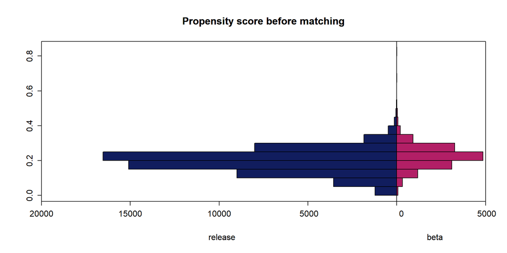

```r
out <- histbackback(split(df_4x_sm$psvalue, df_4x_sm$label), main="Propensity score before matching", xlab=c("release", "beta"))
#! just adding color
barplot(-out$left, col="#111d5e" , horiz=TRUE, space=0, add=TRUE, axes=FALSE)
barplot(out$right, col="#b21f66", horiz=TRUE, space=0, add=TRUE, axes=FALSE)
```

#### Observations

- Important parameters to determine the fit are not only the shape, but also degree of overlap between the two distributions (known as the common support region). By definition, matching only utilizes observations in the region of common support where we are able to obtain matched observations. That is, unmatched observations are excluded from the analysis.
- As can be seen from the figures above, an interval of propensity scores exists, containing both release and beta groups, so that further matching analysis is valid.

## 4. Propensity Score Matching

### Match using Coarsened Exact Matching (CEM)

#### 1x Oversampling

```r
m.cem <- matchit(label ~ active_hours + active_hours_max + uri_count + uri_count_max + search_count + search_count_max + num_pages + num_pages_max + daily_max_tabs + daily_max_tabs_max + daily_unique_domains + daily_unique_domains_max + daily_tabs_opened + daily_tabs_opened_max + num_active_days + daily_num_sessions_started + daily_num_sessions_started_max + session_length + session_length_max + profile_age + cpu_cores + cpu_speed_mhz + cpu_l2_cache_kb + memory_mb + num_bookmarks + FX_PAGE_LOAD_MS_2_PARENT + TIME_TO_DOM_CONTENT_LOADED_END_MS + TIME_TO_NON_BLANK_PAINT_MS + startup_ms + startup_ms_max + content_crashes, data=df_1x_sm, method="cem")
```

```
##
## Using 'treat'='1' as baseline group
```

```r
summary(m.cem)
```

```
##
## Call:
## matchit(formula = label ~ active_hours + active_hours_max + uri_count +
##     uri_count_max + search_count + search_count_max + num_pages +
##     num_pages_max + daily_max_tabs + daily_max_tabs_max + daily_unique_domains +
##     daily_unique_domains_max + daily_tabs_opened + daily_tabs_opened_max +
##     num_active_days + daily_num_sessions_started + daily_num_sessions_started_max +
##     session_length + session_length_max + profile_age + cpu_cores +
##     cpu_speed_mhz + cpu_l2_cache_kb + memory_mb + num_bookmarks +
##     FX_PAGE_LOAD_MS_2_PARENT + TIME_TO_DOM_CONTENT_LOADED_END_MS +
##     TIME_TO_NON_BLANK_PAINT_MS + startup_ms + startup_ms_max +
##     content_crashes, data = df_1x_sm, method = "cem")
##
## Summary of balance for all data:
##                                   Means Treated Means Control   SD Control
## distance                                 0.5283        0.4753       0.1239
## active_hours                             0.8463        0.8226       0.8816
## active_hours_max                         1.6270        1.5749       1.6220
## uri_count                              155.7144      152.5124     202.0505
## uri_count_max                          321.7539      309.3432     472.7794
## search_count                             2.4038        2.4599       4.4994
## search_count_max                         5.4808        5.6510       9.7280
## num_pages                            17282.5955    17121.8589   30523.0558
## num_pages_max                        17468.9180    17314.0807   30635.0412
## daily_max_tabs                           6.1663        9.5413      31.7548
## daily_max_tabs_max                       9.3151       13.6979      40.8305
## daily_unique_domains                     4.9392        5.0764       4.6406
## daily_unique_domains_max                 8.5102        8.7611       9.3051
## daily_tabs_opened                       16.9826       20.4904      35.4585
## daily_tabs_opened_max                   33.1751       39.5674      74.6147
## num_active_days                          5.5737        5.3362       2.2655
## daily_num_sessions_started               2.9114        2.3758       2.7134
## daily_num_sessions_started_max           5.2841        4.2885       4.7841
## session_length                           9.2470       12.2238      14.7877
## session_length_max                      18.2416       22.5061      29.0826
## profile_age                            899.8606      890.9148     761.8498
## cpu_cores                                3.1362        2.9783       1.4816
## cpu_speed_mhz                         2711.7816     2678.9154     651.3179
## cpu_l2_cache_kb                        623.2080      681.7073     987.1069
## memory_mb                             9445.1617     8968.5824    7877.8699
```

[output cut: 202 more lines]

```
## memory_mb                            19.5491  26.6667   8.4739 96.8707
## num_bookmarks                        99.8497   0.0000  91.5960 97.7414
## FX_PAGE_LOAD_MS_2_PARENT             99.1570  55.8013  69.6527 72.8438
## TIME_TO_DOM_CONTENT_LOADED_END_MS    98.1156  61.1905  80.7096 95.7966
## TIME_TO_NON_BLANK_PAINT_MS           97.4919  71.2288  84.6428 94.1979
## startup_ms                           74.5780  40.2247  77.5770 96.2616
## startup_ms_max                       77.3262  45.6449  83.8087 96.8774
## content_crashes                       0.0000   0.0000   0.0000  0.0000
##
## Sample sizes:
##           Control Treated
## All         34867   35133
## Matched      1918    2129
## Unmatched   32949   33004
## Discarded       0       0
```

```r
m.cem.1 = match.data(m.cem)
```

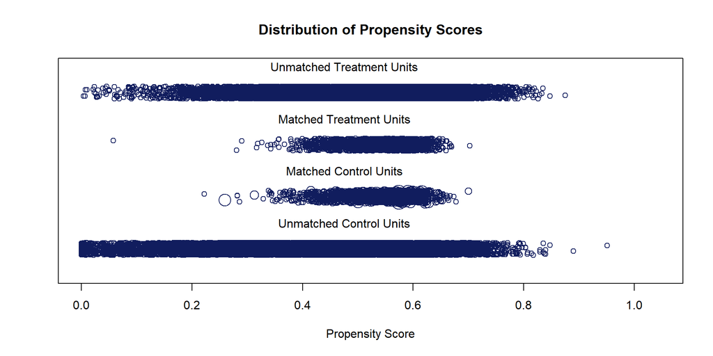

```
## [1] "To identify the units, use first mouse button; to stop, use second."
```

```
## integer(0)
```

```r
plot(m.cem, type = "jitter", col = "#111d5e")
```

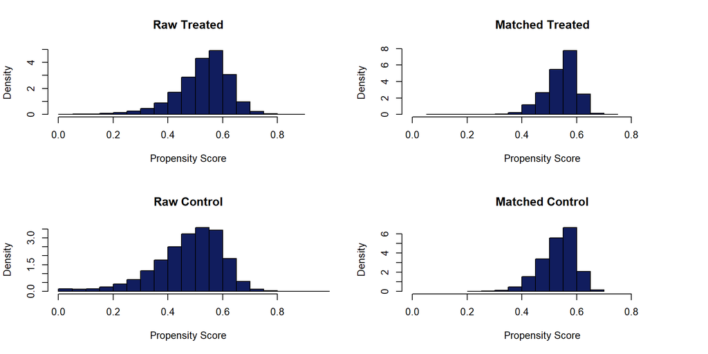

```r
plot(m.cem, type = "hist", col = "#111d5e")
```

#### 2x Oversampling

```r
m.cem <- matchit(label ~ active_hours + active_hours_max + uri_count + uri_count_max + search_count + search_count_max + num_pages + num_pages_max + daily_max_tabs + daily_max_tabs_max + daily_unique_domains + daily_unique_domains_max + daily_tabs_opened + daily_tabs_opened_max + num_active_days + daily_num_sessions_started + daily_num_sessions_started_max + session_length_max + profile_age + cpu_cores + cpu_speed_mhz + cpu_l2_cache_kb + memory_mb + num_bookmarks + FX_PAGE_LOAD_MS_2_PARENT + TIME_TO_DOM_CONTENT_LOADED_END_MS + TIME_TO_NON_BLANK_PAINT_MS + startup_ms + startup_ms_max + content_crashes, data=df_2x_sm, method="cem")
```

```
##
## Using 'treat'='1' as baseline group
```

```r
summary(m.cem)
```

```
##
## Call:
## matchit(formula = label ~ active_hours + active_hours_max + uri_count +
##     uri_count_max + search_count + search_count_max + num_pages +
##     num_pages_max + daily_max_tabs + daily_max_tabs_max + daily_unique_domains +
##     daily_unique_domains_max + daily_tabs_opened + daily_tabs_opened_max +
##     num_active_days + daily_num_sessions_started + daily_num_sessions_started_max +
##     session_length_max + profile_age + cpu_cores + cpu_speed_mhz +
##     cpu_l2_cache_kb + memory_mb + num_bookmarks + FX_PAGE_LOAD_MS_2_PARENT +
##     TIME_TO_DOM_CONTENT_LOADED_END_MS + TIME_TO_NON_BLANK_PAINT_MS +
##     startup_ms + startup_ms_max + content_crashes, data = df_2x_sm,
##     method = "cem")
##
## Summary of balance for all data:
##                                   Means Treated Means Control   SD Control
## distance                                 0.3586        0.3198       0.0944
## active_hours                             0.8497        0.8228       0.8844
## active_hours_max                         1.6328        1.5772       1.6236
## uri_count                              155.8644      152.6388     201.3966
## uri_count_max                          321.4644      310.9981     474.8453
## search_count                             2.4062        2.4606       4.5026
## search_count_max                         5.5083        5.6482       9.6653
## num_pages                            17239.4544    17385.9297   30720.5137
## num_pages_max                        17415.9082    17580.6582   30841.9700
## daily_max_tabs                           6.2964        9.5831      33.0984
## daily_max_tabs_max                       9.4543       13.7687      43.5362
## daily_unique_domains                     4.9950        5.0551       4.6003
## daily_unique_domains_max                 8.6190        8.7399       9.2477
## daily_tabs_opened                       17.2440       20.4062      35.3428
## daily_tabs_opened_max                   33.7932       39.3880      73.6616
## num_active_days                          5.5681        5.3517       2.2595
## daily_num_sessions_started               2.8604        2.3650       2.7118
## daily_num_sessions_started_max           5.1947        4.2731       4.7933
## session_length_max                      18.2874       22.7522      30.5604
## profile_age                            886.1441      896.4296     764.7560
## cpu_cores                                3.1578        2.9727       1.4594
## cpu_speed_mhz                         2717.8253     2676.8851     670.0841
## cpu_l2_cache_kb                        619.0807      678.1463     975.2798
## memory_mb                             9580.5694     8951.0478    7867.7503
## num_bookmarks                          166.1972      245.8025    1329.6540
```

[output cut: 195 more lines]

```
## memory_mb                            91.0876  56.4103  34.2221   96.9339
## num_bookmarks                        86.7737 100.0000  87.0041   98.2498
## FX_PAGE_LOAD_MS_2_PARENT             98.7881  77.8514  85.8572  -37.9575
## TIME_TO_DOM_CONTENT_LOADED_END_MS    93.8210  76.2353  86.4532   90.3656
## TIME_TO_NON_BLANK_PAINT_MS           92.9890  66.4762  85.2088   94.0548
## startup_ms                           86.0400  33.9264  85.3674   96.6889
## startup_ms_max                       92.6655  38.3661  93.3268   98.7426
## content_crashes                       0.0000   0.0000   0.0000    0.0000
##
## Sample sizes:
##           Control Treated
## All         46712   23288
## Matched      3717    2676
## Unmatched   42995   20612
## Discarded       0       0
```

```r
m.cem.2 = match.data(m.cem)
```

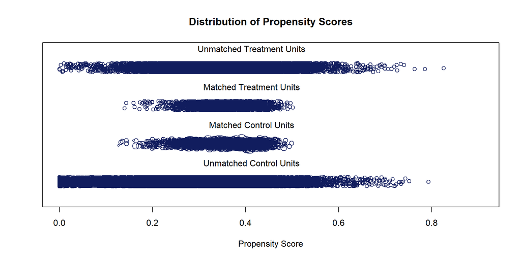

```
## [1] "To identify the units, use first mouse button; to stop, use second."
```

```
## integer(0)
```

```r
plot(m.cem, type = "jitter", col = "#111d5e")
```

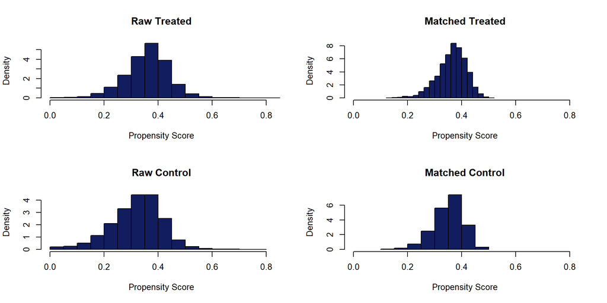

```r
plot(m.cem, type = "hist", col = "#111d5e")
```

#### 4x Oversampling

```r
m.cem <- matchit(label ~ active_hours + active_hours_max + uri_count + uri_count_max + search_count + search_count_max + num_pages + num_pages_max + daily_max_tabs + daily_max_tabs_max + daily_unique_domains + daily_unique_domains_max + daily_tabs_opened + daily_tabs_opened_max + num_active_days + daily_num_sessions_started + daily_num_sessions_started_max + session_length + session_length_max + profile_age + cpu_cores + cpu_speed_mhz + cpu_l2_cache_kb + memory_mb + num_bookmarks + FX_PAGE_LOAD_MS_2_PARENT + TIME_TO_DOM_CONTENT_LOADED_END_MS + TIME_TO_NON_BLANK_PAINT_MS + startup_ms + startup_ms_max + content_crashes, data=df_4x_sm, method="cem")
```

```
##
## Using 'treat'='1' as baseline group
```

```r
summary(m.cem)
```

```
##
## Call:
## matchit(formula = label ~ active_hours + active_hours_max + uri_count +
##     uri_count_max + search_count + search_count_max + num_pages +
##     num_pages_max + daily_max_tabs + daily_max_tabs_max + daily_unique_domains +
##     daily_unique_domains_max + daily_tabs_opened + daily_tabs_opened_max +
##     num_active_days + daily_num_sessions_started + daily_num_sessions_started_max +
##     session_length + session_length_max + profile_age + cpu_cores +
##     cpu_speed_mhz + cpu_l2_cache_kb + memory_mb + num_bookmarks +
##     FX_PAGE_LOAD_MS_2_PARENT + TIME_TO_DOM_CONTENT_LOADED_END_MS +
##     TIME_TO_NON_BLANK_PAINT_MS + startup_ms + startup_ms_max +
##     content_crashes, data = df_4x_sm, method = "cem")
##
## Summary of balance for all data:
##                                   Means Treated Means Control   SD Control
## distance                                 0.2256        0.1936       0.0714
## active_hours                             0.8489        0.8228       0.8868
## active_hours_max                         1.6279        1.5754       1.6230
## uri_count                              157.7101      152.4917     202.1573
## uri_count_max                          326.3804      310.5489     483.2373
## search_count                             2.4087        2.4406       4.4527
## search_count_max                         5.5584        5.6121       9.6019
## num_pages                            17886.6568    17288.7521   30534.1357
## num_pages_max                        18090.7291    17483.2539   30657.4208
## daily_max_tabs                           6.3964        9.5327      32.5515
## daily_max_tabs_max                       9.5468       13.7398      44.8141
## daily_unique_domains                     4.9901        5.0557       4.5978
## daily_unique_domains_max                 8.6079        8.7319       9.2475
## daily_tabs_opened                       17.3348       20.4529      35.6479
## daily_tabs_opened_max                   33.8071       39.5403      76.5937
## num_active_days                          5.5684        5.3456       2.2637
## daily_num_sessions_started               2.9051        2.3679       2.7115
## daily_num_sessions_started_max           5.3065        4.2785       4.8121
## session_length                           9.3463       12.3050      14.7475
## session_length_max                      18.3879       22.6896      29.7740
## profile_age                            892.4113      893.3252     762.7635
## cpu_cores                                3.1605        2.9765       1.4668
## cpu_speed_mhz                         2712.2321     2678.4019     666.4013
## cpu_l2_cache_kb                        623.7074      679.7006     980.6965
## memory_mb                             9421.8057     8969.6724    7967.6262
```

[output cut: 202 more lines]

```
## memory_mb                            98.4034  82.8571   50.7823   90.7040
## num_bookmarks                        88.7569   0.0000   88.2841   97.4113
## FX_PAGE_LOAD_MS_2_PARENT             99.9742  91.1300   88.2321   56.6512
## TIME_TO_DOM_CONTENT_LOADED_END_MS    96.7555  90.6918   88.0225   85.4234
## TIME_TO_NON_BLANK_PAINT_MS           95.3373  89.4040   93.7998   96.5242
## startup_ms                           89.7107  48.8486   84.9724   98.0080
## startup_ms_max                       99.5183  57.1047   89.6699   97.3091
## content_crashes                       0.0000   0.0000    0.0000    0.0000
##
## Sample sizes:
##           Control Treated
## All         56000   14000
## Matched      2488    1426
## Unmatched   53512   12574
## Discarded       0       0
```

```r
m.cem.4 = match.data(m.cem)
```

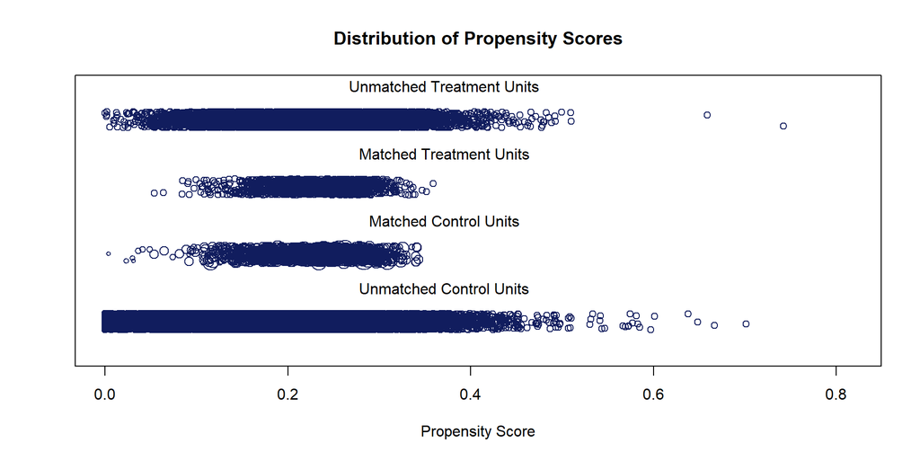

```
## [1] "To identify the units, use first mouse button; to stop, use second."
```

```
## integer(0)
```

```r
plot(m.cem, type = "jitter", col = "#111d5e")
```

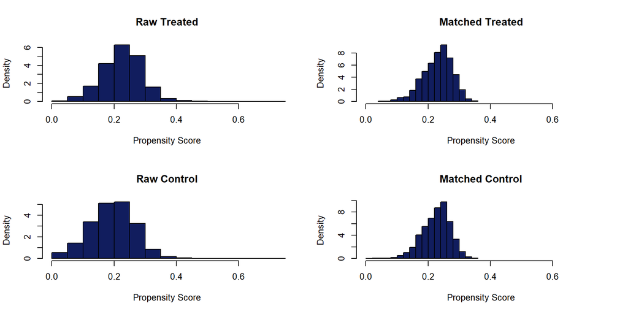

```r
plot(m.cem, type = "hist", col = "#111d5e")
```

### Match using Nearest Neighbor matching

#### 1x Oversampling

```r
m.nn <- matchit(label ~ active_hours + active_hours_max + uri_count + uri_count_max + search_count + search_count_max + num_pages + num_pages_max + daily_max_tabs + daily_max_tabs_max + daily_unique_domains + daily_unique_domains_max + daily_tabs_opened + daily_tabs_opened_max + num_active_days + daily_num_sessions_started + daily_num_sessions_started_max + session_length + session_length_max + profile_age + cpu_cores + cpu_speed_mhz + cpu_l2_cache_kb + memory_mb + num_bookmarks + FX_PAGE_LOAD_MS_2_PARENT + TIME_TO_DOM_CONTENT_LOADED_END_MS + TIME_TO_NON_BLANK_PAINT_MS + startup_ms + startup_ms_max + content_crashes, data=df_1x_sm, method="nearest", replace = TRUE)
summary(m.nn)
```

```
##
## Call:
## matchit(formula = label ~ active_hours + active_hours_max + uri_count +
##     uri_count_max + search_count + search_count_max + num_pages +
##     num_pages_max + daily_max_tabs + daily_max_tabs_max + daily_unique_domains +
##     daily_unique_domains_max + daily_tabs_opened + daily_tabs_opened_max +
##     num_active_days + daily_num_sessions_started + daily_num_sessions_started_max +
##     session_length + session_length_max + profile_age + cpu_cores +
##     cpu_speed_mhz + cpu_l2_cache_kb + memory_mb + num_bookmarks +
##     FX_PAGE_LOAD_MS_2_PARENT + TIME_TO_DOM_CONTENT_LOADED_END_MS +
##     TIME_TO_NON_BLANK_PAINT_MS + startup_ms + startup_ms_max +
##     content_crashes, data = df_1x_sm, method = "nearest", replace = TRUE)
##
## Summary of balance for all data:
##                                   Means Treated Means Control   SD Control
## distance                                 0.5283        0.4753       0.1239
## active_hours                             0.8463        0.8226       0.8816
## active_hours_max                         1.6270        1.5749       1.6220
## uri_count                              155.7144      152.5124     202.0505
## uri_count_max                          321.7539      309.3432     472.7794
## search_count                             2.4038        2.4599       4.4994
## search_count_max                         5.4808        5.6510       9.7280
## num_pages                            17282.5955    17121.8589   30523.0558
## num_pages_max                        17468.9180    17314.0807   30635.0412
## daily_max_tabs                           6.1663        9.5413      31.7548
## daily_max_tabs_max                       9.3151       13.6979      40.8305
## daily_unique_domains                     4.9392        5.0764       4.6406
## daily_unique_domains_max                 8.5102        8.7611       9.3051
## daily_tabs_opened                       16.9826       20.4904      35.4585
## daily_tabs_opened_max                   33.1751       39.5674      74.6147
## num_active_days                          5.5737        5.3362       2.2655
## daily_num_sessions_started               2.9114        2.3758       2.7134
## daily_num_sessions_started_max           5.2841        4.2885       4.7841
## session_length                           9.2470       12.2238      14.7877
## session_length_max                      18.2416       22.5061      29.0826
## profile_age                            899.8606      890.9148     761.8498
## cpu_cores                                3.1362        2.9783       1.4816
## cpu_speed_mhz                         2711.7816     2678.9154     651.3179
## cpu_l2_cache_kb                        623.2080      681.7073     987.1069
## memory_mb                             9445.1617     8968.5824    7877.8699
```

[output cut: 202 more lines]

```
## memory_mb                            93.5787  36.6667  25.3454  -0.0191
## num_bookmarks                        87.8109   0.0000  67.3103   8.5856
## FX_PAGE_LOAD_MS_2_PARENT             95.4635  69.7370  67.4800  56.1685
## TIME_TO_DOM_CONTENT_LOADED_END_MS    93.2275  67.9589  71.8172   0.0000
## TIME_TO_NON_BLANK_PAINT_MS           98.8021  58.7540  70.2724  79.7172
## startup_ms                           98.5965  38.6437  86.0225  90.9128
## startup_ms_max                       99.4032  36.5120  86.5179  88.0074
## content_crashes                       0.0000   0.0000   0.0000   0.0000
##
## Sample sizes:
##           Control Treated
## All         34867   35133
## Matched     18333   35133
## Unmatched   16534       0
## Discarded       0       0
```

```r
m.nn.1 = match.data(m.nn)
```

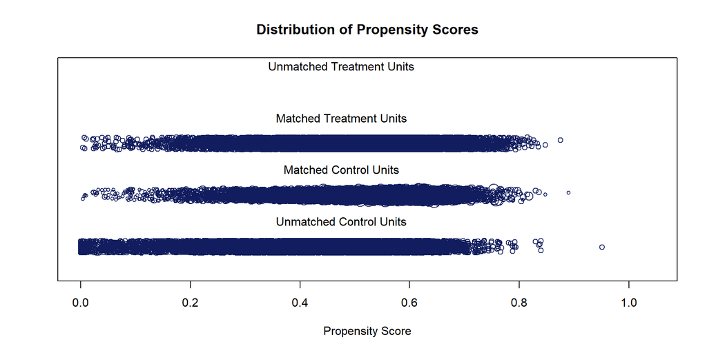

```
## [1] "To identify the units, use first mouse button; to stop, use second."
```

```
## integer(0)
```

```r
plot(m.nn, type = "jitter", col = "#111d5e")
```

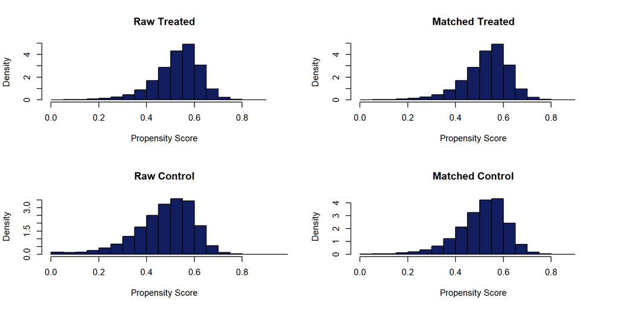

```r
plot(m.nn, type = "hist", col = "#111d5e")
```

#### 2x Oversampling

```r
m.nn <- matchit(label ~ active_hours + active_hours_max + uri_count + uri_count_max + search_count + search_count_max + num_pages + num_pages_max + daily_max_tabs + daily_max_tabs_max + daily_unique_domains + daily_unique_domains_max + daily_tabs_opened + daily_tabs_opened_max + num_active_days + daily_num_sessions_started + daily_num_sessions_started_max + session_length_max + profile_age + cpu_cores + cpu_speed_mhz + cpu_l2_cache_kb + memory_mb + num_bookmarks + FX_PAGE_LOAD_MS_2_PARENT + TIME_TO_DOM_CONTENT_LOADED_END_MS + TIME_TO_NON_BLANK_PAINT_MS + startup_ms + startup_ms_max + content_crashes, data=df_2x_sm, method="nearest", replace = TRUE)
summary(m.nn)
```

```
##
## Call:
## matchit(formula = label ~ active_hours + active_hours_max + uri_count +
##     uri_count_max + search_count + search_count_max + num_pages +
##     num_pages_max + daily_max_tabs + daily_max_tabs_max + daily_unique_domains +
##     daily_unique_domains_max + daily_tabs_opened + daily_tabs_opened_max +
##     num_active_days + daily_num_sessions_started + daily_num_sessions_started_max +
##     session_length_max + profile_age + cpu_cores + cpu_speed_mhz +
##     cpu_l2_cache_kb + memory_mb + num_bookmarks + FX_PAGE_LOAD_MS_2_PARENT +
##     TIME_TO_DOM_CONTENT_LOADED_END_MS + TIME_TO_NON_BLANK_PAINT_MS +
##     startup_ms + startup_ms_max + content_crashes, data = df_2x_sm,
##     method = "nearest", replace = TRUE)
##
## Summary of balance for all data:
##                                   Means Treated Means Control   SD Control
## distance                                 0.3586        0.3198       0.0944
## active_hours                             0.8497        0.8228       0.8844
## active_hours_max                         1.6328        1.5772       1.6236
## uri_count                              155.8644      152.6388     201.3966
## uri_count_max                          321.4644      310.9981     474.8453
## search_count                             2.4062        2.4606       4.5026
## search_count_max                         5.5083        5.6482       9.6653
## num_pages                            17239.4544    17385.9297   30720.5137
## num_pages_max                        17415.9082    17580.6582   30841.9700
## daily_max_tabs                           6.2964        9.5831      33.0984
## daily_max_tabs_max                       9.4543       13.7687      43.5362
## daily_unique_domains                     4.9950        5.0551       4.6003
## daily_unique_domains_max                 8.6190        8.7399       9.2477
## daily_tabs_opened                       17.2440       20.4062      35.3428
## daily_tabs_opened_max                   33.7932       39.3880      73.6616
## num_active_days                          5.5681        5.3517       2.2595
## daily_num_sessions_started               2.8604        2.3650       2.7118
## daily_num_sessions_started_max           5.1947        4.2731       4.7933
## session_length_max                      18.2874       22.7522      30.5604
## profile_age                            886.1441      896.4296     764.7560
## cpu_cores                                3.1578        2.9727       1.4594
## cpu_speed_mhz                         2717.8253     2676.8851     670.0841
## cpu_l2_cache_kb                        619.0807      678.1463     975.2798
## memory_mb                             9580.5694     8951.0478    7867.7503
## num_bookmarks                          166.1972      245.8025    1329.6540
```

[output cut: 195 more lines]

```
## memory_mb                            86.1106  58.9744  40.3226    0.0175
## num_bookmarks                        90.9280   0.0000  72.6086   23.9745
## FX_PAGE_LOAD_MS_2_PARENT             90.6373  95.2161  83.2891   60.6086
## TIME_TO_DOM_CONTENT_LOADED_END_MS    92.2500  87.9831  80.5420   22.6766
## TIME_TO_NON_BLANK_PAINT_MS           97.7321  73.5432  82.2942   70.5046
## startup_ms                           93.6286  45.9161  86.5765   89.3242
## startup_ms_max                       93.5393  45.0626  85.7374   83.3294
## content_crashes                       0.0000   0.0000   0.0000    0.0000
##
## Sample sizes:
##           Control Treated
## All         46712   23288
## Matched     16196   23288
## Unmatched   30516       0
## Discarded       0       0
```

```r
m.nn.2 = match.data(m.nn)
```

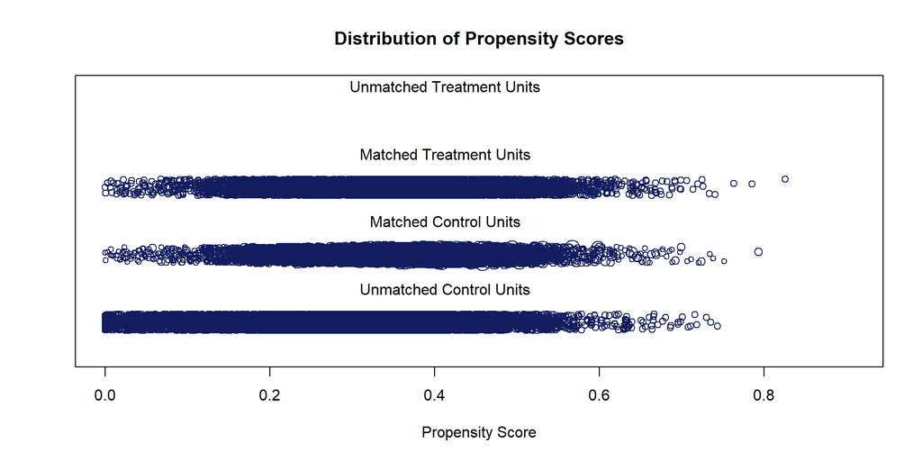

```
## [1] "To identify the units, use first mouse button; to stop, use second."
```

```
## integer(0)
```

```r
plot(m.nn, type = "jitter", col = "#111d5e")
```

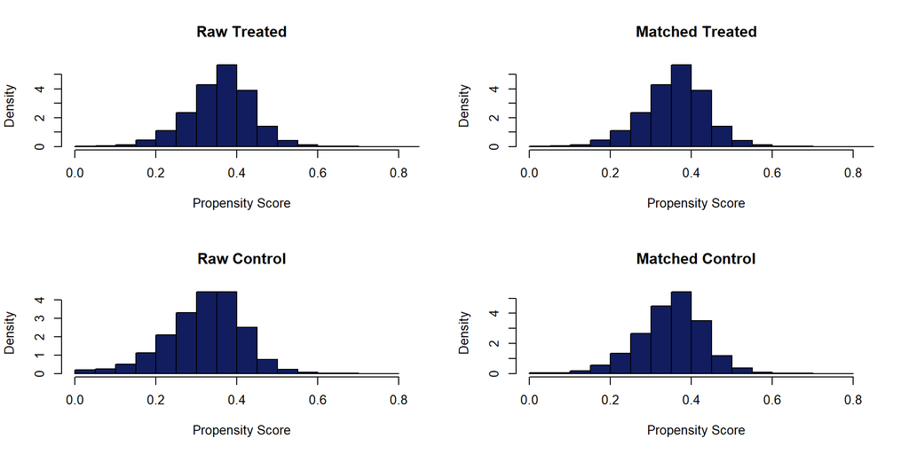

```r
plot(m.nn, type = "hist", col = "#111d5e")
```

#### 4x Oversampling

```r
m.nn <- matchit(label ~ active_hours + active_hours_max + uri_count + uri_count_max + search_count + search_count_max + num_pages + num_pages_max + daily_max_tabs + daily_max_tabs_max + daily_unique_domains + daily_unique_domains_max + daily_tabs_opened + daily_tabs_opened_max + num_active_days + daily_num_sessions_started + daily_num_sessions_started_max + session_length + session_length_max + profile_age + cpu_cores + cpu_speed_mhz + cpu_l2_cache_kb + memory_mb + num_bookmarks + FX_PAGE_LOAD_MS_2_PARENT + TIME_TO_DOM_CONTENT_LOADED_END_MS + TIME_TO_NON_BLANK_PAINT_MS + startup_ms + startup_ms_max + content_crashes, data=df_4x_sm, method="nearest", replace = TRUE)
summary(m.nn)
```

```
##
## Call:
## matchit(formula = label ~ active_hours + active_hours_max + uri_count +
##     uri_count_max + search_count + search_count_max + num_pages +
##     num_pages_max + daily_max_tabs + daily_max_tabs_max + daily_unique_domains +
##     daily_unique_domains_max + daily_tabs_opened + daily_tabs_opened_max +
##     num_active_days + daily_num_sessions_started + daily_num_sessions_started_max +
##     session_length + session_length_max + profile_age + cpu_cores +
##     cpu_speed_mhz + cpu_l2_cache_kb + memory_mb + num_bookmarks +
##     FX_PAGE_LOAD_MS_2_PARENT + TIME_TO_DOM_CONTENT_LOADED_END_MS +
##     TIME_TO_NON_BLANK_PAINT_MS + startup_ms + startup_ms_max +
##     content_crashes, data = df_4x_sm, method = "nearest", replace = TRUE)
##
## Summary of balance for all data:
##                                   Means Treated Means Control   SD Control
## distance                                 0.2256        0.1936       0.0714
## active_hours                             0.8489        0.8228       0.8868
## active_hours_max                         1.6279        1.5754       1.6230
## uri_count                              157.7101      152.4917     202.1573
## uri_count_max                          326.3804      310.5489     483.2373
## search_count                             2.4087        2.4406       4.4527
## search_count_max                         5.5584        5.6121       9.6019
## num_pages                            17886.6568    17288.7521   30534.1357
## num_pages_max                        18090.7291    17483.2539   30657.4208
## daily_max_tabs                           6.3964        9.5327      32.5515
## daily_max_tabs_max                       9.5468       13.7398      44.8141
## daily_unique_domains                     4.9901        5.0557       4.5978
## daily_unique_domains_max                 8.6079        8.7319       9.2475
## daily_tabs_opened                       17.3348       20.4529      35.6479
## daily_tabs_opened_max                   33.8071       39.5403      76.5937
## num_active_days                          5.5684        5.3456       2.2637
## daily_num_sessions_started               2.9051        2.3679       2.7115
## daily_num_sessions_started_max           5.3065        4.2785       4.8121
## session_length                           9.3463       12.3050      14.7475
## session_length_max                      18.3879       22.6896      29.7740
## profile_age                            892.4113      893.3252     762.7635
## cpu_cores                                3.1605        2.9765       1.4668
## cpu_speed_mhz                         2712.2321     2678.4019     666.4013
## cpu_l2_cache_kb                        623.7074      679.7006     980.6965
## memory_mb                             9421.8057     8969.6724    7967.6262
```

[output cut: 202 more lines]

```
## memory_mb                            82.7803  40.0000  30.1411  -50.2216
## num_bookmarks                        87.5855   0.0000  74.4747   57.0548
## FX_PAGE_LOAD_MS_2_PARENT             99.5668  96.1662  85.8839   52.4454
## TIME_TO_DOM_CONTENT_LOADED_END_MS    99.2889  89.8170  87.0522   47.3958
## TIME_TO_NON_BLANK_PAINT_MS           98.6382  89.7713  88.6073   86.9092
## startup_ms                           94.5639  50.9870  90.7371   95.5515
## startup_ms_max                       95.0024  49.3657  93.6805   95.9152
## content_crashes                       0.0000   0.0000   0.0000    0.0000
##
## Sample sizes:
##           Control Treated
## All         56000   14000
## Matched     11448   14000
## Unmatched   44552       0
## Discarded       0       0
```

```r
m.nn.4 = match.data(m.nn)
```

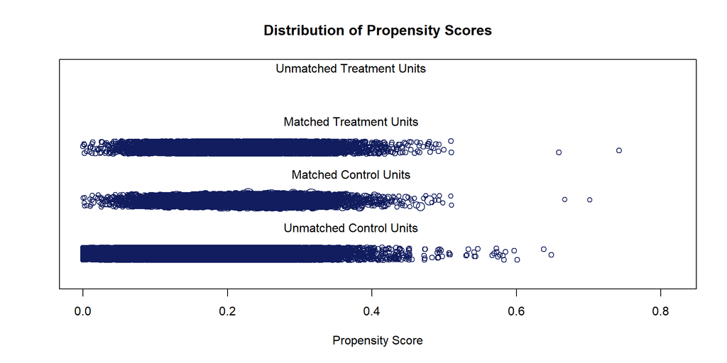

```
## [1] "To identify the units, use first mouse button; to stop, use second."
```

```
## integer(0)
```

```r
plot(m.nn, type = "jitter", col = "#111d5e")
```

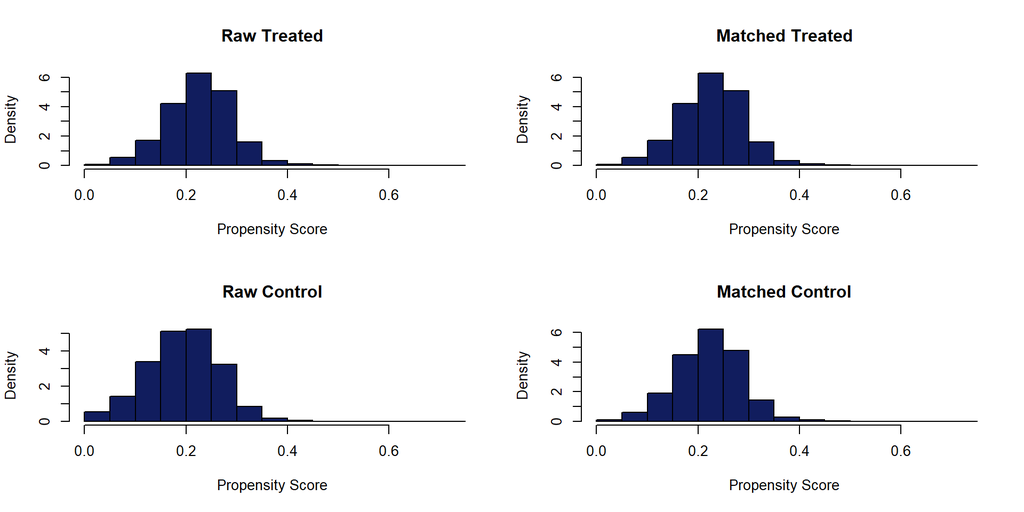

```r
plot(m.nn, type = "hist", col = "#111d5e")
```

### Observations

- What we want to see is that the Matched Treated (beta) and Matched Control (release) distributions are roughly similar. So, we can do better.

## 5. Computing indices of covariate imbalance after matching

### 1x Oversampling

#### CEM

```r
### 1. Standardized difference
cov1 <- m.cem.1 %>% select(c(engagement, usage, environment, page_load, startup, stability))
treated1 <- (m.cem.1$label==FALSE)
std.diff1 <- apply(cov1,2,function(x) 100*(mean(x[treated1])- mean(x[!treated1]))/(sqrt(0.5*(var(x[treated1]) + var(x[!treated1])))))
sort(abs(std.diff1))
```

```
##                  search_count_max                     uri_count_max
##                        0.05191727                        0.26776351
##                   cpu_l2_cache_kb                         uri_count
##                        0.34511766                        0.34904936
##             daily_tabs_opened_max                   num_active_days
##                        0.49110937                        1.09216177
##                  active_hours_max                      search_count
##                        1.23366903                        1.40430548
##                session_length_max                      active_hours
##                        2.31747507                        2.69938504
##                 daily_tabs_opened                     num_bookmarks
##                        3.42661143                        3.83681070
##              daily_unique_domains                     num_pages_max
##                        4.09326878                        4.60120558
##          daily_unique_domains_max                         num_pages
##                        4.81982523                        4.87984619
##                     cpu_speed_mhz                       profile_age
##                        5.16219936                        5.44904027
##                    session_length                daily_max_tabs_max
##                        5.59035957                        6.48785239
##    daily_num_sessions_started_max                    daily_max_tabs
##                        6.84180211                        7.68754476
##        TIME_TO_NON_BLANK_PAINT_MS TIME_TO_DOM_CONTENT_LOADED_END_MS
##                        8.37687355                       10.44653033
##        daily_num_sessions_started                    startup_ms_max
##                       10.49938233                       11.00333654
##                         cpu_cores          FX_PAGE_LOAD_MS_2_PARENT
##                       11.06422129                       11.43117715
##                         memory_mb                        startup_ms
##                       11.47830341                       12.73513746
##        TIME_TO_DOM_INTERACTIVE_MS           TIME_TO_DOM_COMPLETE_MS
##                       14.38500263                       16.41248044
##         TIME_TO_LOAD_EVENT_END_MS                   timezone_offset
##                       17.74406561                       48.41805489
##                        num_addons
##                      106.68660853
```

```r
### 2. chi-square test
xBalance(label ~ (active_hours + active_hours_max + uri_count + uri_count_max + search_count + search_count_max + num_pages + num_pages_max + daily_max_tabs + daily_max_tabs_max + daily_unique_domains + daily_unique_domains_max + daily_tabs_opened + daily_tabs_opened_max + num_active_days + daily_num_sessions_started + daily_num_sessions_started_max + session_length + session_length_max + profile_age + cpu_cores + cpu_speed_mhz + cpu_l2_cache_kb + memory_mb + num_bookmarks + FX_PAGE_LOAD_MS_2_PARENT + TIME_TO_DOM_CONTENT_LOADED_END_MS + TIME_TO_NON_BLANK_PAINT_MS + startup_ms + startup_ms_max + content_crashes), data=m.cem.1, report=c("chisquare.test"))
```

```
## ---Overall Test---
##         chisquare df  p.value
## unstrat      89.6 30 7.56e-08
## ---
## Signif. codes:  0 '***' 0.001 '** ' 0.01 '*  ' 0.05 '.  ' 0.1 '   ' 1
```

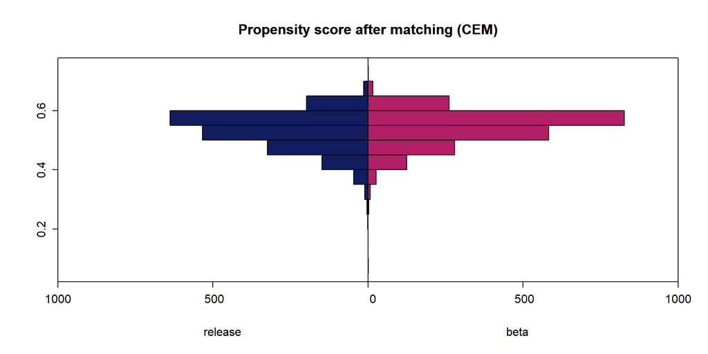

```r
out <- histbackback(split(m.cem.1$psvalue, m.cem.1$label), main= "Propensity score after matching (CEM)", xlab=c("release", "beta"))
barplot(-out$left, col="#111d5e" , horiz=TRUE, space=0, add=TRUE, axes=FALSE)
barplot(out$right, col="#b21f66", horiz=TRUE, space=0, add=TRUE, axes=FALSE)
```

#### NN

```r
### 1. Standardized difference
cov1 <- m.nn.1 %>% select(c(engagement, usage, environment, page_load, startup, stability))
treated1 <- (m.nn.1$label==FALSE)
std.diff1 <- apply(cov1,2,function(x) 100*(mean(x[treated1])- mean(x[!treated1]))/(sqrt(0.5*(var(x[treated1]) + var(x[!treated1])))))
sort(abs(std.diff1))
```

```
##                      search_count                       profile_age
##                         0.1099822                         0.1430815
##                  search_count_max                     num_pages_max
##                         0.1539358                         0.3752503
##                         num_pages              daily_unique_domains
##                         0.3764235                         0.5091710
##          daily_unique_domains_max                      active_hours
##                         0.7319276                         1.3616892
##                    startup_ms_max                         uri_count
##                         1.3746645                         1.6029286
##                     cpu_speed_mhz                  active_hours_max
##                         1.6523125                         1.8635366
##                     uri_count_max                         memory_mb
##                         2.2156688                         2.3736731
##                   cpu_l2_cache_kb                        startup_ms
##                         2.3802101                         2.6870580
##             daily_tabs_opened_max                     num_bookmarks
##                         2.9708781                         3.6599637
##                 daily_tabs_opened                   num_active_days
##                         3.8822946                         3.9699615
##                         cpu_cores TIME_TO_DOM_CONTENT_LOADED_END_MS
##                         4.3217843                         5.5326123
##                session_length_max                daily_max_tabs_max
##                         5.8194709                         5.9033672
##                    daily_max_tabs        TIME_TO_NON_BLANK_PAINT_MS
##                         5.9964006                         7.9611779
##                    session_length          FX_PAGE_LOAD_MS_2_PARENT
##                         8.6075216                         8.6271282
##        daily_num_sessions_started    daily_num_sessions_started_max
##                         8.8401553                         9.2609118
##        TIME_TO_DOM_INTERACTIVE_MS           TIME_TO_DOM_COMPLETE_MS
##                        15.4268673                        15.5995268
##         TIME_TO_LOAD_EVENT_END_MS                   timezone_offset
##                        18.1261432                        44.5397338
##                        num_addons
##                        79.8881258
```

```r
### 2. chi-square test
xBalance(label ~ (active_hours + active_hours_max + uri_count + uri_count_max + search_count + search_count_max + num_pages + num_pages_max + daily_max_tabs + daily_max_tabs_max + daily_unique_domains + daily_unique_domains_max + daily_tabs_opened + daily_tabs_opened_max + num_active_days + daily_num_sessions_started + daily_num_sessions_started_max + session_length + session_length_max + profile_age + cpu_cores + cpu_speed_mhz + cpu_l2_cache_kb + memory_mb + num_bookmarks + FX_PAGE_LOAD_MS_2_PARENT + TIME_TO_DOM_CONTENT_LOADED_END_MS + TIME_TO_NON_BLANK_PAINT_MS + startup_ms + startup_ms_max + content_crashes), data=m.nn.1, report=c("chisquare.test"))
```

```
## ---Overall Test---
##         chisquare df  p.value
## unstrat       403 30 6.12e-67
## ---
## Signif. codes:  0 '***' 0.001 '** ' 0.01 '*  ' 0.05 '.  ' 0.1 '   ' 1
```

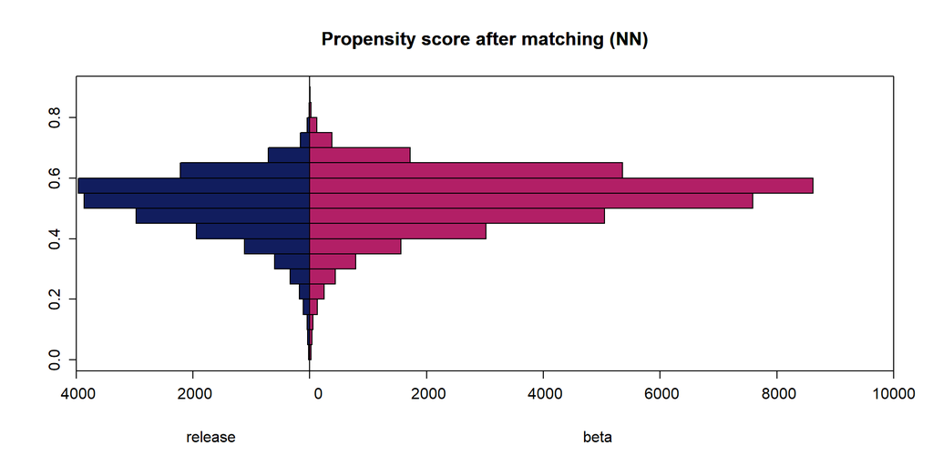

```r
out <- histbackback(split(m.nn.1$psvalue, m.nn.1$label), main= "Propensity score after matching (NN)", xlab=c("release", "beta"))
barplot(-out$left, col="#111d5e" , horiz=TRUE, space=0, add=TRUE, axes=FALSE)
barplot(out$right, col="#b21f66", horiz=TRUE, space=0, add=TRUE, axes=FALSE)
```

### 2x Oversampling

#### CEM

```r
### 1. Standardized difference
cov1 <- m.cem.2 %>% select(c(engagement, usage, environment, page_load, startup, stability))
treated1 <- (m.cem.2$label==FALSE)
std.diff1 <- apply(cov1,2,function(x) 100*(mean(x[treated1])- mean(x[!treated1]))/(sqrt(0.5*(var(x[treated1]) + var(x[!treated1])))))
sort(abs(std.diff1))
```

```
##                       profile_age                 daily_tabs_opened
##                         0.6061886                         2.1259190
##                   num_active_days             daily_tabs_opened_max
##                         3.2404952                         3.8669458
##          FX_PAGE_LOAD_MS_2_PARENT                   cpu_l2_cache_kb
##                         4.3657883                         5.1882565
##                     num_bookmarks TIME_TO_DOM_CONTENT_LOADED_END_MS
##                         5.4421351                         6.3251920
##                    startup_ms_max                     cpu_speed_mhz
##                         6.6616223                         6.8073659
##                  search_count_max                      search_count
##                         6.9981045                         7.0447409
##                         memory_mb        TIME_TO_NON_BLANK_PAINT_MS
##                         7.1713249                         7.4314703
##                         uri_count                daily_max_tabs_max
##                         7.4933949                         8.7720308
##                     num_pages_max                         num_pages
##                         8.9977024                         9.1598871
##                     uri_count_max                  active_hours_max
##                         9.3330253                        10.4889685
##              daily_unique_domains                    daily_max_tabs
##                        11.3824530                        11.4874671
##          daily_unique_domains_max                      active_hours
##                        11.9496700                        12.1033918
##                        startup_ms           TIME_TO_DOM_COMPLETE_MS
##                        12.7541608                        13.2847284
##                         cpu_cores        TIME_TO_DOM_INTERACTIVE_MS
##                        13.5227931                        13.7621637
##         TIME_TO_LOAD_EVENT_END_MS                session_length_max
##                        14.8342459                        15.6021484
##                    session_length    daily_num_sessions_started_max
##                        20.6304533                        23.2666254
##        daily_num_sessions_started                   timezone_offset
##                        24.6813285                        48.3412020
##                        num_addons
##                       101.4274200
```

```r
### 2. chi-square test
xBalance(label ~ (active_hours + active_hours_max + uri_count + uri_count_max + search_count + search_count_max + num_pages + num_pages_max + daily_max_tabs + daily_max_tabs_max + daily_unique_domains + daily_unique_domains_max + daily_tabs_opened + daily_tabs_opened_max + num_active_days + daily_num_sessions_started + daily_num_sessions_started_max + session_length_max + profile_age + cpu_cores + cpu_speed_mhz + cpu_l2_cache_kb + memory_mb + num_bookmarks + FX_PAGE_LOAD_MS_2_PARENT + TIME_TO_DOM_CONTENT_LOADED_END_MS + TIME_TO_NON_BLANK_PAINT_MS + startup_ms + startup_ms_max + content_crashes), data=m.cem.2, report=c("chisquare.test"))
```

```
## ---Overall Test---
##         chisquare df  p.value
## unstrat       250 29 5.54e-37
## ---
## Signif. codes:  0 '***' 0.001 '** ' 0.01 '*  ' 0.05 '.  ' 0.1 '   ' 1
```

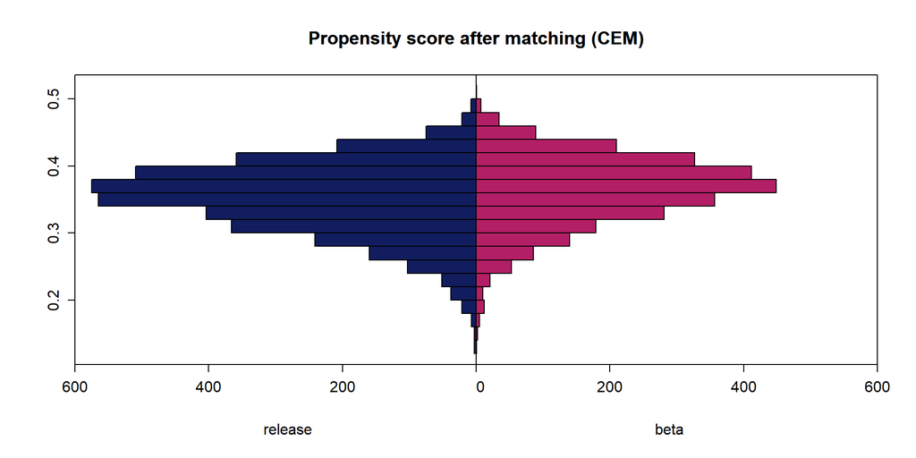

```r
out <- histbackback(split(m.cem.2$psvalue, m.cem.2$label), main= "Propensity score after matching (CEM)", xlab=c("release", "beta"))
barplot(-out$left, col="#111d5e" , horiz=TRUE, space=0, add=TRUE, axes=FALSE)
barplot(out$right, col="#b21f66", horiz=TRUE, space=0, add=TRUE, axes=FALSE)
```

#### NN

```r
### 1. Standardized difference
cov1 <- m.nn.2 %>% select(c(engagement, usage, environment, page_load, startup, stability))
treated1 <- (m.nn.2$label==FALSE)
std.diff1 <- apply(cov1,2,function(x) 100*(mean(x[treated1])- mean(x[!treated1]))/(sqrt(0.5*(var(x[treated1]) + var(x[!treated1])))))
sort(abs(std.diff1))
```

```
##                  search_count_max                      search_count
##                       0.002946652                       0.285728679
##                       profile_age          daily_unique_domains_max
##                       0.560590639                       0.676995418
##                     uri_count_max                     num_pages_max
##                       0.702412736                       0.754078816
##                         num_pages                   num_active_days
##                       0.809352710                       1.024836295
##                  active_hours_max                         uri_count
##                       1.176271002                       1.203003130
##              daily_unique_domains                      active_hours
##                       1.221405715                       1.580650734
##             daily_tabs_opened_max                 daily_tabs_opened
##                       1.597879410                       1.690069522
##                    startup_ms_max                     num_bookmarks
##                       2.010753360                       2.289138016
##                     cpu_speed_mhz                   cpu_l2_cache_kb
##                       2.302661768                       2.359159623
##                         memory_mb                        startup_ms
##                       2.664357223                       2.859441887
## TIME_TO_DOM_CONTENT_LOADED_END_MS                daily_max_tabs_max
##                       3.171258125                       3.388681684
##                    daily_max_tabs                         cpu_cores
##                       3.547791709                       3.573543740
##                session_length_max          FX_PAGE_LOAD_MS_2_PARENT
##                       3.848497369                       4.164038827
##        TIME_TO_NON_BLANK_PAINT_MS        daily_num_sessions_started
##                       4.860276141                       6.022321461
##    daily_num_sessions_started_max                    session_length
##                       6.047584284                      10.359135132
##        TIME_TO_DOM_INTERACTIVE_MS           TIME_TO_DOM_COMPLETE_MS
##                      12.325841379                      12.374063365
##         TIME_TO_LOAD_EVENT_END_MS                   timezone_offset
##                      15.006205522                      44.392371847
##                        num_addons
##                      78.032534972
```

```r
### 2. chi-square test
xBalance(label ~ (active_hours + active_hours_max + uri_count + uri_count_max + search_count + search_count_max + num_pages + num_pages_max + daily_max_tabs + daily_max_tabs_max + daily_unique_domains + daily_unique_domains_max + daily_tabs_opened + daily_tabs_opened_max + num_active_days + daily_num_sessions_started + daily_num_sessions_started_max + session_length_max + profile_age + cpu_cores + cpu_speed_mhz + cpu_l2_cache_kb + memory_mb + num_bookmarks + FX_PAGE_LOAD_MS_2_PARENT + TIME_TO_DOM_CONTENT_LOADED_END_MS + TIME_TO_NON_BLANK_PAINT_MS + startup_ms + startup_ms_max + content_crashes), data=m.nn.2, report=c("chisquare.test"))
```

```
## ---Overall Test---
##         chisquare df  p.value
## unstrat       121 29 3.16e-13
## ---
## Signif. codes:  0 '***' 0.001 '** ' 0.01 '*  ' 0.05 '.  ' 0.1 '   ' 1
```

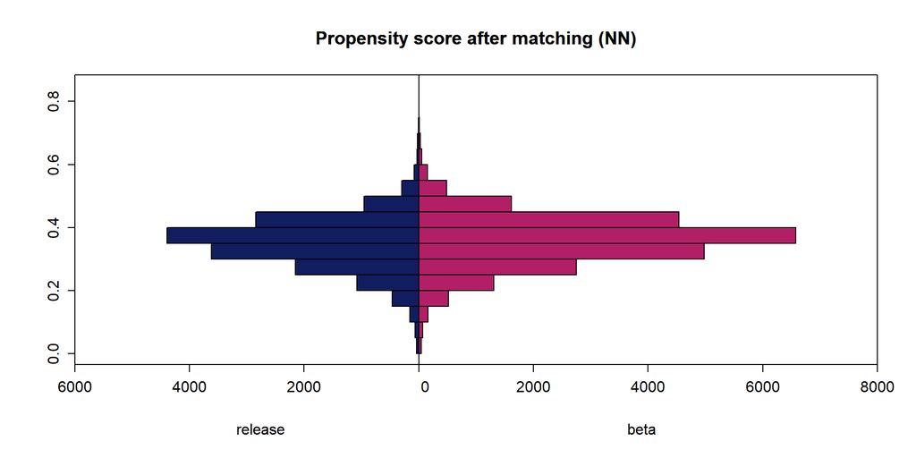

```r
out <- histbackback(split(m.nn.2$psvalue, m.nn.2$label), main= "Propensity score after matching (NN)", xlab=c("release", "beta"))
barplot(-out$left, col="#111d5e" , horiz=TRUE, space=0, add=TRUE, axes=FALSE)
barplot(out$right, col="#b21f66", horiz=TRUE, space=0, add=TRUE, axes=FALSE)
```

### 4x Oversampling

#### CEM

```r
### 1. Standardized difference
cov1 <- m.cem.4 %>% select(c(engagement, usage, environment, page_load, startup, stability))
treated1 <- (m.cem.4$label==FALSE)
std.diff1 <- apply(cov1,2,function(x) 100*(mean(x[treated1])- mean(x[!treated1]))/(sqrt(0.5*(var(x[treated1]) + var(x[!treated1])))))
sort(abs(std.diff1))
```

```
##                 daily_tabs_opened        TIME_TO_DOM_INTERACTIVE_MS
##                         0.3282969                         0.3649426
##             daily_tabs_opened_max        TIME_TO_NON_BLANK_PAINT_MS
##                         0.6298427                         0.7434557
##                    startup_ms_max          FX_PAGE_LOAD_MS_2_PARENT
##                         0.9286874                         2.2931684
##                     cpu_speed_mhz                    daily_max_tabs
##                         2.5896467                         2.7935407
## TIME_TO_DOM_CONTENT_LOADED_END_MS                    session_length
##                         2.9193727                         3.7177953
##                         memory_mb                     num_bookmarks
##                         4.3439633                         5.0447883
##                daily_max_tabs_max           TIME_TO_DOM_COMPLETE_MS
##                         5.3033208                         5.8547054
##                session_length_max                        startup_ms
##                         7.1089134                         7.2014410
##                   num_active_days         TIME_TO_LOAD_EVENT_END_MS
##                         7.4041964                         7.4052691
##                   cpu_l2_cache_kb                       profile_age
##                         7.7337790                         8.4154365
##                  search_count_max                      search_count
##                        10.0242481                        10.5078942
##                         cpu_cores                  active_hours_max
##                        11.9812983                        13.6117851
##                         uri_count                         num_pages
##                        14.9835807                        15.5061665
##                     num_pages_max                     uri_count_max
##                        15.5751717                        15.8328689
##                      active_hours          daily_unique_domains_max
##                        15.8737185                        15.9041822
##              daily_unique_domains    daily_num_sessions_started_max
##                        17.3535728                        19.5149695
##        daily_num_sessions_started                   timezone_offset
##                        19.5293391                        50.5768410
##                        num_addons
##                       109.5913237
```

```r
### 2. chi-square test
xBalance(label ~ (active_hours + active_hours_max + uri_count + uri_count_max + search_count + search_count_max + num_pages + num_pages_max + daily_max_tabs + daily_max_tabs_max + daily_unique_domains + daily_unique_domains_max + daily_tabs_opened + daily_tabs_opened_max + num_active_days + daily_num_sessions_started + daily_num_sessions_started_max + session_length + session_length_max + profile_age + cpu_cores + cpu_speed_mhz + cpu_l2_cache_kb + memory_mb + num_bookmarks + FX_PAGE_LOAD_MS_2_PARENT + TIME_TO_DOM_CONTENT_LOADED_END_MS + TIME_TO_NON_BLANK_PAINT_MS + startup_ms + startup_ms_max + content_crashes), data=m.cem.4, report=c("chisquare.test"))
```

```
## ---Overall Test---
##         chisquare df  p.value
## unstrat       180 30 2.68e-23
## ---
## Signif. codes:  0 '***' 0.001 '** ' 0.01 '*  ' 0.05 '.  ' 0.1 '   ' 1
```

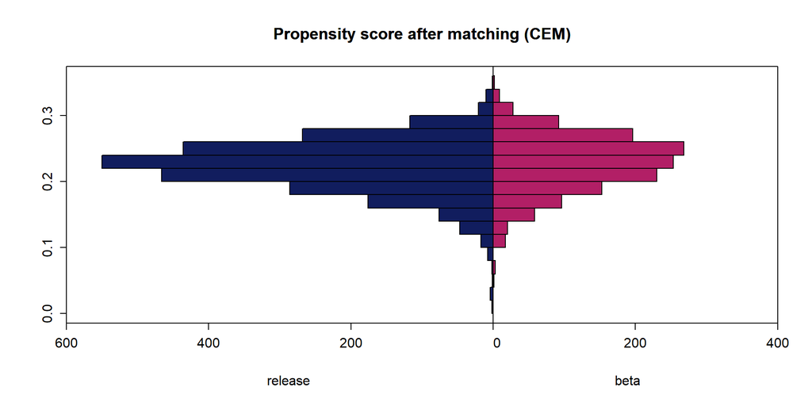

```r
out <- histbackback(split(m.cem.4$psvalue, m.cem.4$label), main= "Propensity score after matching (CEM)", xlab=c("release", "beta"))
barplot(-out$left, col="#111d5e" , horiz=TRUE, space=0, add=TRUE, axes=FALSE)
barplot(out$right, col="#b21f66", horiz=TRUE, space=0, add=TRUE, axes=FALSE)
```

#### NN

```r
### 1. Standardized difference
cov1 <- m.nn.4 %>% select(c(engagement, usage, environment, page_load, startup, stability))
treated1 <- (m.nn.4$label==FALSE)
std.diff1 <- apply(cov1,2,function(x) 100*(mean(x[treated1])- mean(x[!treated1]))/(sqrt(0.5*(var(x[treated1]) + var(x[!treated1])))))
sort(abs(std.diff1))
```

```
##                  active_hours_max                      active_hours
##                        0.01986732                        0.08669301
##                       profile_age                session_length_max
##                        0.30835123                        0.31464926
##                         num_pages                     num_pages_max
##                        0.45248504                        0.50274274
##                         uri_count                     uri_count_max
##                        0.52615064                        0.63742006
##                   num_active_days                      search_count
##                        0.83059109                        0.83650403
##                  search_count_max             daily_tabs_opened_max
##                        1.03656996                        1.10850906
##              daily_unique_domains                    startup_ms_max
##                        1.11519532                        1.13006810
##          daily_unique_domains_max                    session_length
##                        1.14966286                        1.16211948
##                   cpu_l2_cache_kb                 daily_tabs_opened
##                        1.22001382                        1.29129680
##                    daily_max_tabs                daily_max_tabs_max
##                        1.57211676                        1.57420819
##                         memory_mb                     cpu_speed_mhz
##                        1.59194543                        1.65063078
## TIME_TO_DOM_CONTENT_LOADED_END_MS                     num_bookmarks
##                        2.32514058                        2.35295849
##                        startup_ms                         cpu_cores
##                        2.51050105                        3.25342925
##        TIME_TO_NON_BLANK_PAINT_MS        daily_num_sessions_started
##                        3.40839270                        3.60251273
##          FX_PAGE_LOAD_MS_2_PARENT    daily_num_sessions_started_max
##                        3.76780295                        4.62985053
##        TIME_TO_DOM_INTERACTIVE_MS           TIME_TO_DOM_COMPLETE_MS
##                       10.65935482                       11.04355071
##         TIME_TO_LOAD_EVENT_END_MS                   timezone_offset
##                       13.68058609                       42.81529631
##                        num_addons
##                       80.28988535
```

```r
### 2. chi-square test
xBalance(label ~ (active_hours + active_hours_max + uri_count + uri_count_max + search_count + search_count_max + num_pages + num_pages_max + daily_max_tabs + daily_max_tabs_max + daily_unique_domains + daily_unique_domains_max + daily_tabs_opened + daily_tabs_opened_max + num_active_days + daily_num_sessions_started + daily_num_sessions_started_max + session_length + session_length_max + profile_age + cpu_cores + cpu_speed_mhz + cpu_l2_cache_kb + memory_mb + num_bookmarks + FX_PAGE_LOAD_MS_2_PARENT + TIME_TO_DOM_CONTENT_LOADED_END_MS + TIME_TO_NON_BLANK_PAINT_MS + startup_ms + startup_ms_max + content_crashes), data=m.nn.4, report=c("chisquare.test"))
```

```
## ---Overall Test---
##         chisquare df p.value
## unstrat      46.5 30  0.0277
## ---
## Signif. codes:  0 '***' 0.001 '** ' 0.01 '*  ' 0.05 '.  ' 0.1 '   ' 1
```

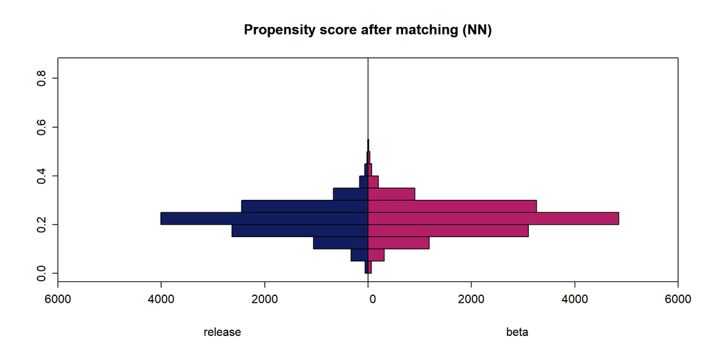

```r
out <- histbackback(split(m.nn.4$psvalue, m.nn.4$label), main= "Propensity score after matching (NN)", xlab=c("release", "beta"))
barplot(-out$left, col="#111d5e" , horiz=TRUE, space=0, add=TRUE, axes=FALSE)
barplot(out$right, col="#b21f66", horiz=TRUE, space=0, add=TRUE, axes=FALSE)
```